# 挑战杯正文

**比亚迪墨西哥建厂推迟——**

**国际政治经济学透视**

**摘 要**

本文以比亚迪墨西哥建厂推迟事件为核心，关注一个国际政治经济学意义上的关键问题：比亚迪已在墨西哥实现销量增长、渠道扩张，并形成一定程度的社会、网络与地域嵌入，为何仍未能完成建厂这一关键生产性嵌入？文章综合地缘政治竞争、依附理论、武器化相互依存与经济泛安全化等视角，采用案例分析与跨案例比较相结合的方法，对比亚迪在墨西哥的市场进入、本地化实践及建厂受阻机制展开研究。研究认为，该项目受阻并非一般意义上的企业经营失误，而是地缘政治竞争、制度约束与三方博弈共同作用的结果。基于此，本文进一步提炼出一套用于识别中国高技术制造业在敏感地区出海风险的分析框架，并提出相应实践启示。

**关键词：**比亚迪；墨西哥；出海；地缘政治；经济泛安全化

**目录**

**1. 引言** 6

> **1.1 研究背景** 6

> **1.2 研究问题与核心观点** 7

> **1.3 文献综述** 8

> **1.4 研究思路、研究意义与文章结构** 9

**2. 理论框架** 10

> **2.1 底层理论：地缘政治竞争** 11

> **2.2 中间机制** 12

> 2.2.1 依附理论 12

> 2.2.2 武器化相互依存理论 13

> 2.2.3 经济泛安全化 14

> 2.2.4 地缘经济 15

> **2.3 理论框架的搭建逻辑** 15

**3. 比亚迪在墨西哥的出海情况** 17

> **3.1 墨西哥市场的战略价值与进入策略** 17

> 3.1.1 墨西哥市场的战略价值 17

> 3.1.2 比亚迪出海墨西哥的战略举措 18

> 3.1.3 嵌入基础与分析过渡 20

> **3.2 比亚迪墨西哥市场嵌入程度** 21

> 3.2.1 社会嵌入 21

> 3.2.2 网络嵌入 23

> 3.2.3 地域嵌入 24

> 3.2.4 维度互动与综合评价 25

**4. 比亚迪在墨西哥推迟建厂的归因分析** 26

> **4.1 “唐罗主义”——美国的“势力范围”之争** 27

> **4.2 “中心-外围”结构——墨西哥对美国的依附关系** 28

> **4.3 “网络性权力”享有者——美国将依附关系“武器化”** 29

> **4.4 新能源汽车产业的特殊性** 30

> **4.5 贸易投资“泛政治化”——中美墨共同采取地缘经济手段** 31

> **4.6 囚徒困境——中美墨三方拒绝合作的僵局** 33

**5. 比亚迪墨西哥建厂受阻的多维解释框架：提出、检验与修正** 34

> **5.1 框架提出与问题界定** 34

> **5.2 维度界定与指标设计** 35

> 5.2.1 地缘政治锚定强度 36

> 5.2.2 外部压力可规避性 36

> 5.2.3 母国—东道国政策协同度 37

> 5.2.4 制度性政策交换空间 37

> **5.3 跨案例比较与维度验证** 38

> **5.4 框架修正与企业能动性** 41

**6. 总结与反思** 42

> **6.1 研究总结** 42

> **6.2 理论反思** 43

> **6.3 实践反思** 44

> **6.4 研究展望** 45

**参考文献** 45

**图目录**

**图1 2023—2025年中国汽车与新能源汽车出口变化情况** 7

**图2 跨国企业在东道国本地化受阻归因的理论框架** 11

**图3 2016至2029年墨西哥电动汽车收入预测** 18

**图4 2018年至2023年墨西哥汽车制造业从业人员数量** 18

**图5 比亚迪在墨西哥的售后服务网点分布图** 20

**图6 比亚迪在墨西哥的销售门店分布** 20

**图9 比亚迪在墨西哥推迟建厂的归因分析框架** 27

**图10 第五章分析框架的两阶段判断逻辑** 42

**表目录**

**表1 比亚迪出海墨西哥历程梳理** 19

**表2 比亚迪墨西哥建厂停滞对三个嵌入维度的影响** 26

**表3 中美墨三方在“囚徒困境”下的博弈格局表** 34

**表4 四维度核心问题、理论来源及主要观察点** 38

**表5 跨案例比较的关键观察点** 39

**1. 引言**

**1.1 研究背景**

中国新能源汽车出海正在从“产品出口”转向“产业链出海”。据中国汽车工业协会发布的数据，2025年中国汽车出口达到709.8万辆，同比增长21.1%；其中新能源汽车出口261.5万辆，同比增长约1倍，新能源汽车已经成为拉动中国汽车出口增长的核心力量。<sup>[1]</sup> 与传统商品出口相比，新能源汽车出海不仅涉及产品销售，更涉及电池、数据、智能系统、供应链和生产网络的跨境布局，因此天然带有更强的制度敏感性和地缘政治含义。如图1所示，2023—2025年中国汽车出口规模持续扩大，新能源汽车出口则在2025年出现明显跃升，显示出中国汽车出海已进入以新能源为核心驱动力的新阶段。<sup>[2][3]</sup>

在这一背景下，墨西哥成为中国车企出海美洲市场时最受关注的目的地之一。其原因并不复杂：一方面，墨西哥毗邻美国，并处于北美制造网络的关键节点；另一方面，《美墨加协定》（USMCA）为其提供了连接北美市场的制度通道。与此同时，中国与拉美和加勒比国家的经贸往来也在持续扩大，2025年中拉贸易额达到3.93万亿元人民币，约合5652.8亿美元，同比增长6.5%。<sup>[4]</sup> 正因兼具市场潜力、区位优势与规则敏感性，墨西哥成为观察中国高技术制造业在敏感地区推进本地化生产的重要案例。

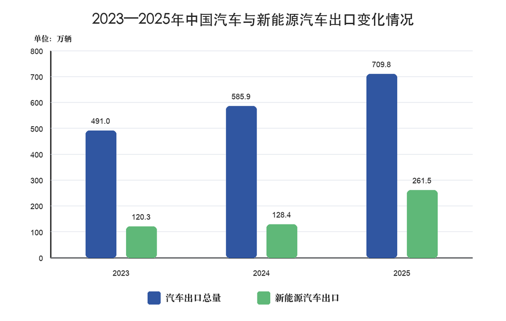

**图1 2023—2025年中国汽车与新能源汽车出口变化情况**

注：单位为万辆。根据中国汽车工业协会发布的2023—2025年汽车工业数据整理绘制。2024年中国汽车出口为585.9万辆，新能源汽车出口为128.4万辆；2023年中国汽车出口为491万辆，新能源汽车出口为120.3万辆。<sup>[2][3]</sup>

这正是本文选题的起点。本文关注的不是一般意义上的“比亚迪出海墨西哥”，而是比亚迪在墨西哥已经取得一定市场基础的前提下，为什么仍未能完成建厂这一决定性生产性嵌入。正因如此，这一案例已经超出了企业市场扩张成败的经验总结，而成为观察中国高技术制造业在敏感地区推进本地化生产时所受结构约束的一个关键切口。

**1.2 研究问题与核心观点**

本文试图回答的核心问题是：在市场拓展、渠道建设和初步本土化布局已经取得进展的条件下，比亚迪为何仍然无法在墨西哥完成建厂？进一步说，是什么力量使一个在经济逻辑上原本具备可行性的投资项目，最终在母国、东道国与第三方市场的共同作用下陷入停滞？

围绕这一问题，本文基于依附理论、武器化相互依存、经济泛安全化与地缘政治竞争等视角，搭建一个多层次、多主体联动的分析框架，用以解释比亚迪在墨西哥建厂受阻的深层原因。本文认为，比亚迪墨西哥建厂受阻，并非单一企业战略失误，也并非单纯的成本收益计算结果，而是地缘政治竞争和经济泛安全化共同作用下的结构性产物。在这一过程中，美国对中国新能源汽车的安全化审视、墨西哥在北美制度框架中的政策收缩、中国对技术外溢的审慎态度相互叠加，最终使“市场进入”与“生产落地”之间出现明显断裂。

因此，本文的研究重点不在于重复说明比亚迪为何选择墨西哥，也不在线性罗列企业出海历程，而在于解释一个更具理论意义的悖论：为什么市场嵌入可以推进，生产嵌入却被卡住；为什么经济上看似合理的投资，在政治上却不断被阻滞。正是在这个意义上，比亚迪墨西哥建厂事件不只是企业个案，而是当前中国高技术制造业出海困境的一个缩影。

**1.3 文献综述**

现有与本文相关的研究，主要集中于中国对拉美投资、全球价值链重组与近岸外包、经济安全化与投资审查三条路径。这些研究为理解中国资本进入拉美及墨西哥的背景提供了重要基础，但在解释比亚迪墨西哥建厂受阻这一问题时，仍存在明显不足。

第一类研究聚焦中国与拉美之间的宏观经贸关系以及中国对拉美的直接投资结构，重点讨论资源合作、基础设施建设和中拉经贸依赖关系。Rhys Jenkins 指出，中国在拉美的“一带一路”推进，更多表现为对既有经贸联系的延续与重新命名，而非区域生产结构的根本改造。Boston University Global Development Policy Center 的《China-Latin America and the Caribbean Economic Bulletin》以及 Enrique Dussel Peters 对中国在拉美对外直接投资的持续跟踪，也都表明中国资本在拉美的行业分布长期具有资源和传统工业导向。<sup>[8][9][10]</sup> 这一路径有助于把握中国资本进入拉美的总体格局，但其分析对象多为能源、矿产、交通等传统领域，对新能源汽车等高技术制造业的系统讨论明显不足，因而难以解释比亚迪这类企业在生产落地阶段所面临的特殊约束。

第二类研究围绕全球价值链重组、近岸外包和墨西哥制造业的承接能力展开。这类研究通常强调，墨西哥依托地理位置、产业基础和贸易协定，在北美供应链重组中具有重要地位。Gary Gereffi 关于墨西哥近岸外包的研究指出，墨西哥的确可能成为承接战略产业转移的重要平台，但其能否真正从中获益，并不只取决于成本和区位，也取决于美国产业政策、规则调整与北美供应链重构的方向。<sup>[11][12]</sup> 这一视角较好解释了墨西哥为何会成为中国车企关注的建厂候选地，也揭示了生产布局与北美市场准入之间的制度联系。然而，这类研究总体上仍以产业网络和区位条件为分析重心，对规则政治、身份标签和第三方市场对东道国政策的实际牵制讨论不足，因此难以进一步说明为何比亚迪可以在墨西哥卖车，却难以在墨西哥建厂。

第三类研究集中在经济安全化、投资审查以及技术敏感产业的治理逻辑上。OECD关于投资与国家安全的研究指出，随着地缘政治竞争升温，越来越多国家将投资筛查、安全审查和供应链控制作为常态化政策工具，国家安全因素正在日益深度地嵌入跨境投资决策。<sup>[13]</sup> 与此相近，围绕美国对华技术竞争、北美汽车规则及USMCA运行的讨论也越来越强调，新能源汽车、数据系统和关键零部件已经不再只是市场竞争对象，而被纳入更广义的战略竞争框架。USTR于2024年发布的USMCA汽车贸易报告，以及 Baker Institute 关于USMCA审议和中国因素的研究，都显示中国企业在墨西哥的汽车投资已经成为北美规则讨论中的重要变量。<sup>[14][15]</sup> 这一研究路径较接近本文的问题意识，但现有讨论大多停留在制度和政策层面，对单个企业建厂项目如何在三方压力传导中被一步步冻结，缺乏更细致的解释。

除上述三类研究外，现有文献在分析层级上还普遍存在一个共同问题，即多以“母国—东道国”双边关系为基本单位。无论是中国对拉美投资研究，还是关于墨西哥制造业升级与产业承接的讨论，往往更多关注中国与墨西哥的双边互动，或东道国自身的制度条件，而较少把第三方市场，特别是美国的规则、关税和安全化压力，作为独立变量纳入同一分析框架。这导致现有研究虽然能够解释“为什么去墨西哥”，却较难解释“为什么去了、适应了市场之后仍无法建厂”。

据此可以看到，现有研究至少存在三方面缺口：其一，研究对象上，对拉美投资的讨论仍更多围绕资源型或传统制造业投资展开，对新能源汽车等高技术制造业的关注不足；其二，解释机制上，现有研究往往分别讨论区位优势、全球价值链、投资安全化等因素，但缺少一个能够将产业技术敏感性、制度规则约束与第三方市场压力传导纳入同一分析框架的解释路径；其三，问题聚焦上，关于比亚迪墨西哥案例的现有讨论多停留于市场扩张或舆论争议层面，对“市场进入成功而生产落地受阻”这一核心悖论缺乏专门分析。本文正是在这一文献缺口上展开，试图将研究重心从一般性的“出海叙事”推进到“建厂受阻”这一更能暴露结构约束的关键环节。

**1.4 研究思路、研究意义与文章结构**

为回答上述问题，本文采取“问题提出—文献回顾—理论建构—案例分析—框架提炼—比较检验”的写作思路。本文在第一部分从比亚迪墨西哥建厂受阻这一事件切入，明确研究对象与问题意识，并在文献综述基础上指出现有解释的不足；第二部分整合武器化相互依存、经济泛安全化与地缘政治竞争三条理论线索，搭建理论框架基础；第三部分考察比亚迪在墨西哥的市场嵌入举措及成效，说明企业并非没有进展，而是已经形成一定程度的社会、网络与地域嵌入，由此引出核心问题。第四部分聚焦建厂受阻事件本身及其初步归因，在前文构建起的理论框架下解释多方压力如何传导并造成项目停滞。第五部分进一步提出新的分析维度与解释框架，并通过横向比较检验其解释力。最后，第六部分总结研究发现，并提出相应的理论和实践启示。

本文的理论意义在于，从“建厂受阻”而非“产品出海”出发，重新审视高技术制造业跨国投资的解释逻辑。通过把比亚迪墨西哥建厂事件置于“母国—东道国—第三方市场”的三角关系中，本文试图说明，当前中国高技术制造业面临的约束条件已经不再只是传统外国直接投资（Foreign Direct Investment, FDI）理论强调的区位优势、成本收益与企业能力，而是越来越受到地缘政治竞争、制度规则与安全化叙事的共同塑造。本文的实践意义在于，为中国新能源汽车企业识别海外投资风险提供一个更具穿透力的判断框架，尤其帮助区分哪些压力可以通过本地化经营加以对冲，哪些压力本质上属于企业难以单独突破的结构性约束。

**2. 理论框架**

为解释比亚迪在墨西哥建厂推迟的原因，本研究以中美墨三国关系结构为理论情境，构建了一个多层次、多主体联动的理论框架，为分析跨国企业在东道国本地化受阻现象提供一个解读范式。这一理论框架的主体包括跨国企业所涉及的母国、东道国和第三方国家。作为深层结构性因素，地缘政治竞争构成本理论框架的起点。与此同时，该框架整合了依附论、武器化相互依存、经济泛安全化、地缘经济等理论，形成两条分析路径，以此作为中间因素来分析母国、东道国和第三方国家共同采取相关限制性措施并导致囚徒困境、跨国企业本地化策略受挫的原因。下图显示主要理论及各理论间的逻辑关系。

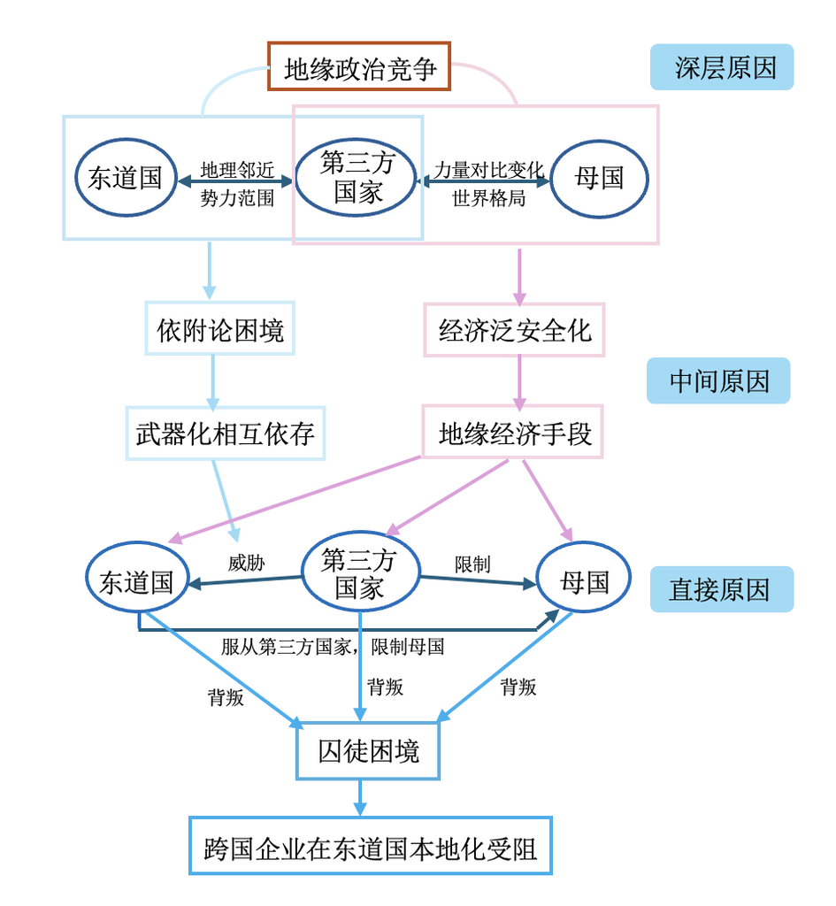

**图2 跨国企业在东道国本地化受阻归因的理论框架**

图表来源：笔者自制

**2.1 底层理论：地缘政治竞争**

地缘政治学（Geopolitics）研究地理要素在国家的对外政策和国际关系中的作用、其影响的地理范围的形成和各种国家集团及其影响的地理范围的形成。地理要素在实施对外政策和发展国际关系中是构成地缘政治的基础<sup>[16]</sup>。

“地缘政治学”这一术语由瑞典地理学家鲁道夫·契伦（Rudolf Kjellén）首次提出，他借鉴德国地理学家弗里德里希·拉策尔（Friedrich Ratzel）创立的政治地理学，将地缘政治学定义为国家作为空间范围的科学<sup>[17]</sup>。其核心思想是“地理决定政治”，认为国家必须通过扩张“生存空间”来维持生命力和权力。这一生存空间不仅指有形的地理空间（包括领土、自然资源、绝对位置、相对位置等），还指无形的空间，也即势力范围（Sphere of Influence）。势力范围是指一个大国通过政治、经济、军事或文化手段，在特定地理区域内对其他国家或地区拥有的排他性主导权或控制权。此后，美国著名地缘政治学家尼古拉斯·斯皮克曼（Nicholas Spykman）也指出一国领土的自然特性将会直接影响到一国维持安全的方式，因为实力在很大程度上取决于一国的地理位置和自然资源<sup>[17]</sup>。由此，世界主要国家的地缘政治利益都包括要扩大自己的对外经济和对外政治影响的地理范围，即确保和扩大自身的势力范围。<sup>[16]</sup>

在地缘政治学的基础上，地缘政治竞争（Geopolitical Competition）可以被理解为国家之间基于自然禀赋导致的空间异质性而对不同的地理空间展开的争夺。控制了关键性自然空间就意味着国家可以以此为核心，向周边辐射影响力，从而在地缘竞争中占据主动权和优势地位<sup>[18]</sup>。在本研究中，我们将主要讨论地缘政治竞争在经济上的体现，具体而言，是其对全球价值链和跨国企业的影响。地缘政治竞争对全球价值链的影响主要体现在以下三方面：首先是地理空间重构层面。产业回流、近岸布局与友岸合作等政策，不再单纯基于运输成本或比较优势，而是基于战略信任与联盟关系进行空间重组。其次，在市场空间层面，企业决策逻辑发生转变。在地缘政治风险上升的环境中，企业改变以往效率最大化的目标，转而将政治稳定性、制度可预测性与政策持续性纳入成本结构考量。最后，在制度规则空间层面，地缘政治竞争体现为规则解释权和制度制定权的争夺。总体来说，通过改变空间布局逻辑、调整市场激励结构和重塑制度规则环境，地缘政治竞争对企业跨国投资与第三方国家政策选择产生了深远影响。

**2.2 中间机制**

动荡世界格局之下的地缘政治竞争加剧是该框架的底层理论，在此底层理论与跨国企业本地化受阻的直接原因之间起到连接作用的是两条主要中间机制路径。在本研究的情境下，母国、东道国与第三方国家之间存在复杂的三角关系：一方面，由于地理上的邻近性，东道国处于辐射能力较强的第三方国家的势力范围内；另一方面，由于母国对第三方国家的国际地位存在潜在威胁，两者之间存在较强的竞争关系。因此，在中间机制部分，我们将分别从第三方国家与母国、东道国的关系性质入手，运用依附理论、武器化相互依存理论、经济泛安全化和地缘经济理论，搭建两条逻辑链条。

2.2.1 依附理论

依附理论（Dependency Theory）的核心概念“中心-外围”或“核心-边缘”依附关系由阿根廷学者劳尔·普雷维什（Raúl Prebisch）首先提出。他认为，当今的世界经济已经形成了一个体系，在这个体系中，西方发达资本主义国家处于“中心”位置，而非西方的不发达的发展中国家处于“外围”位置。“中心”与“外围”的政治经济关系是不平等的。<sup>[19]</sup>由于中心国家在资金、技术、市场等方面具有相对于非西方国家的巨大优势，外围国家被强行锁定在初级和低端产品的产业链上。这种国际经济体系结构加强了中心国家通过不公正贸易对外围国家的经济剥削和政治控制，而这正是外围国家贫穷落后的根本原因。此后的学者特奥托尼奥·多斯桑托斯（Theotonio dos Santos）进一步对“依附”进行了阐释。他提出，“所谓依附，我们指的是这样的情况：某些国家的经济取决于它们所从属的另外一些经济的发展与扩展。”<sup>[20]</sup>

在本研究的情境下，我们认为地理上的邻近性使经济上的依附更为容易且依附关系更深厚、复杂。外围国家对中心国家在经贸上的依赖关系导致其自身经济的脆弱性更高，为维护自身经济利益必须对中心国家做出某种形式的让步。更进一步，这种经济上的依附关系会演化为外围国家对中心国家政治上的依附。中心国家可以利用其综合优势作为筹码干涉外围国家内政，削弱外围国家的政策自主权。

2.2.2 武器化相互依存理论

武器化相互依存理论（Weaponized Interdependence）是由美国政治学者亨利·法雷尔（Henry Farrell）和亚伯拉罕·纽曼（Abraham Newman）首先提出。他们将武器化相互依赖定义为“在非对称网络结构中一些国家能够利用相互依赖的关系来胁迫其他国家”<sup>[21]</sup>。丹尼尔·德雷兹纳将其进一步定义为，“行为体可以利用其在嵌入式网络中的地位，获得与受限系统中其他行为体讨价还价的优势。”<sup>[22]</sup>

武器化相互依存的核心概念是“网络性权力”，它的核心逻辑是：全球网络由节点和连线构成，中心节点在网络中具有更强的支配和控制能力，处于中心位置的国家可以通过不对称依赖关系作为武器来胁迫外围国家。网络关键节点国家将依存关系武器化的主要机制是“瓶颈效应”（Chokepoint Effect），即中心国家由于控制了关键节点，因此能够切断或威胁切断网络连接来胁迫网络上其他国家服从中心国家政策和利益。具体来讲，该机制的运作模式是A国主动切断或减少与B国的联系，利用B国在相互依存关系中的敏感性和脆弱性，以损害B国利益或向B国施压，迫使其改变政策，从而实现A国自身的政治、安全或其他目标。<sup>[23]</sup>

与此同时，武器化相互依存理论也强调权力的行使并不一定以显性对抗或公开制裁的形式出现，而可能通过合规要求、行政审查、技术标准解释权等方式体现。其权力逻辑嵌入在规则体系之中，使得经济政策在形式上保持合法性，但在实质上却具有明显的战略意图。因此，该理论为理解FDI制度风险提供了结构性解释基础：当某一投资活动深度嵌入全球网络时，其制度命运可能取决于网络中其他国家的政策取向，而不仅由东道国市场条件决定。

2.2.3 经济泛安全化

地缘政治竞争和大国博弈体现在经济层面上表现为经济“泛”安全化。经济泛安全化趋势是在经济安全的名义下建立的一套逻辑体系。为了实现经济安全目标，它制定并实施一系列超常规的政治性和安全性政策手段。它意图模糊“经济安全”的有效边界，并试图将一切经济问题用政治、安全的理论框架去解读、套用，导致经济问题出现低效化、无效化的现象。<sup>[24]</sup>总体而言，它不具有经济理性，更多是对“国家安全例外”的滥用。

“安全化”（Securitization）理论由哥本哈根学派提出，它挑战了传统现实主义对“安全”的狭隘定义，认为安全并非客观存在，而是通过话语实践被“制造”为政治议题。<sup>[25]</sup>此后，国内学者进一步将“经济安全化”定义为“政治安全逻辑超越经济逻辑、国家逻辑超越市场逻辑的一种对外政治经济策略。”<sup>[26]</sup>具体而言，它体现为国家以安全受到威胁为理由将贸易、投资等经济活动“泛政治化”，用政治安全思维干预本国的对外经济活动。“经济泛安全化”正是在这样的政治炒作下形成的一种经济保护主义的具体表现，其实质是为了实现自身经济利益及战略利益的最大化，而不惜放弃经济合作及共享所产生相对利益最大化。

经济泛安全化有以下四点主要表现：第一，推动关键产业地理布局的回流、近岸化发展。近岸化和友岸化有利于降低关键产业的对外依赖，并提高其抗风险能力和供应链韧性；第二，投资政策中基于国别和意识形态的风险识别与歧视以及盟友之间产业链供应链的区域合作；第三，收紧涉及高新技术等在内的敏感信息的战略管控，构筑技术及信息的安全壁垒；最后，征收惩罚性高额关税和实施其他限制性经贸措施，减少来自外部的进口竞争，保护国内相关企业及产业的发展。这一举措通过各种经贸和产业工具来遏制竞争对手以降低其产品的竞争力。<sup>[24]</sup>

简而言之，对跨国企业来说，经济泛安全化意味着投资活动被纳入更为复杂的制度结构中。企业不仅要考虑市场准入与成本结构，还必须评估安全框架下的政治风险。

2.2.4 地缘经济

地缘经济理论由爱德华·卢特沃克（Edward Luttwak）正式提出，用来描述冷战后的国际体系。他认为地缘经济是以经济手段代替军事手段来实现国家战略目标的竞争形态，最终的结果是“冲突逻辑与经济方法相混合”，使经济和安保紧密地联系在一起。<sup>[27]</sup>此后，地缘经济学的定义得到补充和深化：它被解释为“经济实力的地缘战略性使用”，是为了控制具有明显地域特征的某些特定地区而利用的经济手段，这些特定地区为一国提供维持权力的经济基础或势力范围。

地缘经济隶属于地缘政治，它作为一种手段服务于地缘战略。地缘经济利用经济手段推进国家利益和实现战略目标，国家行为体会运用经济手段来推进地缘政治目标。<sup>[28]</sup>地缘经济的具体手段主要表现为经济制裁。经济制裁会影响对方国家的经济，从而胁迫对方国家实现政策让步或妥协，达到预期政策目标。在经济制裁之外，地缘经济的工具还包括贸易和投资政策、金融和货币政策、能源政策、援助方案、网络手段、技术脱钩和禁运等。最终，地缘经济通过经济手段促进国家供应链安全，维持国家战略产业竞争优势，并通过经济来投射政治影响力，塑造有利于本国的国际制度和体系。

**2.3 理论框架的搭建逻辑**

在本研究中我们主要关注的两对关系是东道国与第三方国家以及母国与第三方国家的关系，这两对关系本质上都受到当前国际体系下地缘政治竞争加剧的深刻影响，但它们各自代表两种不同的国家间关系和对外政策逻辑，因此在中间机制部分我们提出了两条不同的分析路径。最终它们都导向了跨国公司在东道国本地化受阻的直接原因，即东道国、母国和第三方国家这三个行为体同时采取限制性政策措施，而非采取对跨国公司有利的合作姿态，导致博弈论中的囚徒困境和纳什均衡，最后三方陷入僵局，跨国企业本地化目标暂时搁置。

第一条分析路径旨在解释第三方国家为何能通过威胁的方式促使东道国做出让步，从而限制跨国企业在东道国的本地化进程。首先，第三方国家之所以要介入母国的跨国公司在东道国的商业活动的主要原因之一就在于东道国处于第三方国家势力范围的核心位置。东道国处于地缘政治的敏感地带，跨国公司在东道国的经济存在使第三方国家的势力范围受到潜在威胁，因此第三方国家决定通过干涉东道国政策来限制跨国公司的本地化。第三方国家能够介入东道国内政的根本原因在于这两国之间存在结构性的“中心-外围”依附关系，这种不平等的依附关系使得第三方国家对东道国有极大的控制力。依附论主要停留在系统性和结构性的宏观层面，而第三方国家运用这种依附关系来威胁东道国的具体行动层面则需要用武器化相互依存理论来进一步解释。正是因为第三方国家将这种依附关系 “武器化”，它才得以迫使东道国在政策上做出让步，部分牺牲自己的长期经济利益，来配合第三方国家的安全利益。

第二条分析路径则旨在解释为何最终三个行为体同时对跨国企业采取限制性政策措施。这条分析路径从母国与第三方国家的关系入手：母国作为快速崛起的新兴大国对长期处于领导地位的第三方国家构成了挑战，这两者的力量对比变化为世界体系和格局注入了不确定性。第三方国家为了维护自己的国际地位采取各种防御政策，这种地缘政治竞争策略在经济方面的体现就是“经济泛安全化”。经济泛安全化作为一种指导思想和话语建构，使政治安全逻辑超越了经济逻辑，使得纯粹的商业活动被泛政治化。这种经济泛安全化逻辑体系促使第三方国家和母国同时采取地缘经济手段来维护自身的国家安全利益和地缘政治战略。

在这两条分析路径的同时作用下，母国、东道国和第三方国家共同选择“背叛”，即采取不利于跨国公司利益的政策，且这三方都不愿做出妥协，因此最后导致博弈论中的囚徒困境和纳什均衡的结果。囚徒困境（Prisoner’s Dilemma）的核心思想是当每个人都追求自身的利益，最终导致的是集体的悲剧。这是一个个体的理性选择会导致集体非理性结果的典型博弈模型。在囚徒困境中，母国、东道国和第三方国家都想选择对自身最有利的策略，因此共同选择背叛，由此构成了“纳什均衡”（Nash Equilibrium）。在这一非合作博弈中，纳什均衡指的是任何参与者单方面改变策略都无法获得更高收益，因此最终形成了稳定状态，也即三方中任何一方都不愿意做出改变来取得合作的僵局。这使得跨国公司受到三个主要行为体的压力，无法同时满足三方的要求，也无法取得成功进行企业本地化的运作空间，因此最终跨国公司的本地化进程因多方受阻而搁置。

综合上述分析，可以看出本研究的理论框架同时关注底层理论、中间机制和直接原因这三个层次，以及东道国、母国和第三方国家这三个主要行为体，搭建了两条主要的中间机制分析路径，最终运用博弈论来解释三方政策的直接结果并进行收束。

**3. 比亚迪在墨西哥的出海情况**

本章旨在说明，比亚迪在墨西哥并非缺乏市场推进动作，而是已经围绕市场进入、本地化经营和初步联结展开了较系统的布局。比亚迪的全球化进程经历了由电池和电子业务出海，到以新能源公交、大巴为主的商用车出海，再到以乘用车为核心的新一轮出海三个阶段；当前企业正从单纯整车出口转向更强调品牌和本地化的全球布局。<sup>[29]</sup>

**3.1 墨西哥市场的战略价值与进入策略**

3.1.1 墨西哥市场的战略价值

墨西哥之所以在比亚迪全球化布局中具有突出地位，主要在于其兼具市场潜力、制造基础和区位制度优势。如图3和图4所示，墨西哥新能源汽车市场保持增长，汽车制造业具备较强的人力和产业配套基础，为后续本地化生产提供了承接条件。同时，墨西哥毗邻美国，处于北美制造网络关键节点，并通过《美墨加协定》（USMCA）获得进入北美市场的制度通道。此外，墨西哥与多国签有自由贸易和投资协定，能够形成面向美洲并辐射其他地区的规则和关税网络。正因如此，墨西哥不只是销售市场，更是比亚迪连接拉美与北美的重要战略支点。<sup>[30]</sup>

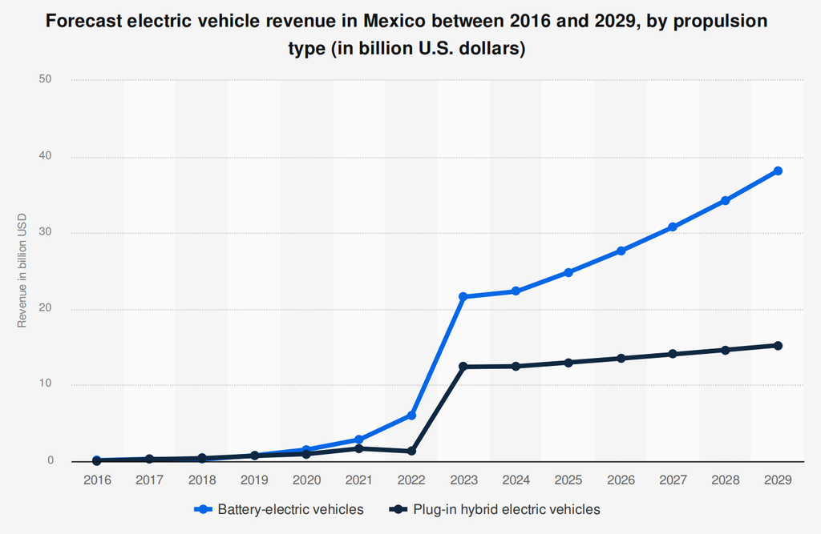

**图3 2016至2029年墨西哥电动汽车收入预测（来源：statista）**

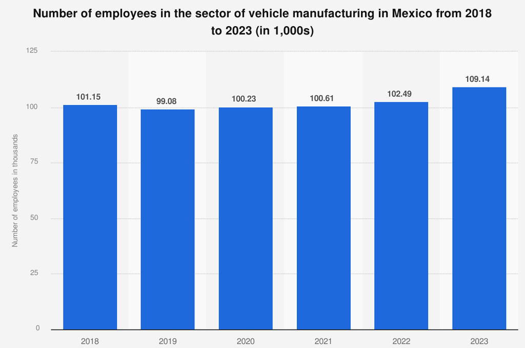

**图4 2018年至2023年墨西哥汽车制造业从业人员数量（来源：statista）**

3.1.2 比亚迪出海墨西哥的战略举措

比亚迪进入墨西哥并非单点突破，而是沿着“商用车先行—乘用车扩张—本地化筹划”的路径逐步推进（见表1）。这一进入路径既体现了其全球化阶段转换的延续，也为后续多项本地化举措的展开提供了时间顺序和业务基础。<sup>[29]</sup>

[output not shown]

**表1 比亚迪出海墨西哥历程梳理**

图表来源：笔者自制

围绕这一进入路径，比亚迪在墨西哥并未停留于单一的产品销售，而是逐步形成了涵盖产品导入、渠道铺设、金融支持与生态配套的组合式策略，以推动市场扩张与本地化经营同步展开。

在产品导入上，比亚迪采取了“分层递进、梯度覆盖”的策略：早期以电动大巴、冷藏车等商用车切入市场，先建立项目经验与品牌信誉；随后密集导入元PLUS、海豚、海豹等主流乘用车，扩大大众消费覆盖；近两年又借助SHARK皮卡和腾势品牌进入更细分、更多层次的市场，形成由商用车到乘用车、由大众市场到高端市场的产品布局。

在渠道铺设上，比亚迪形成了“经销商合作+零售嵌入”的双轨模式。一方面，企业与本地大型经销商集团合作，在墨西哥城、蒙特雷、瓜达拉哈拉等核心城市布局销售与服务网点；另一方面，借助利物浦百货等零售场景设置展示与销售终端，以提高品牌曝光和消费触达。如图5和图6所示，比亚迪的渠道网络已覆盖墨西哥多个主要城市。

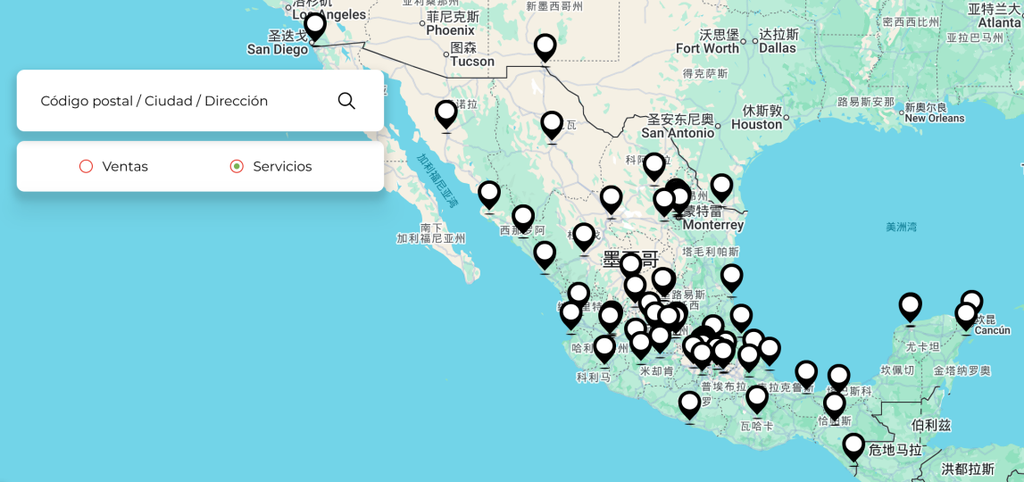

**图5 比亚迪在墨西哥的售后服务网点分布图（来源：BYD Mexico）**

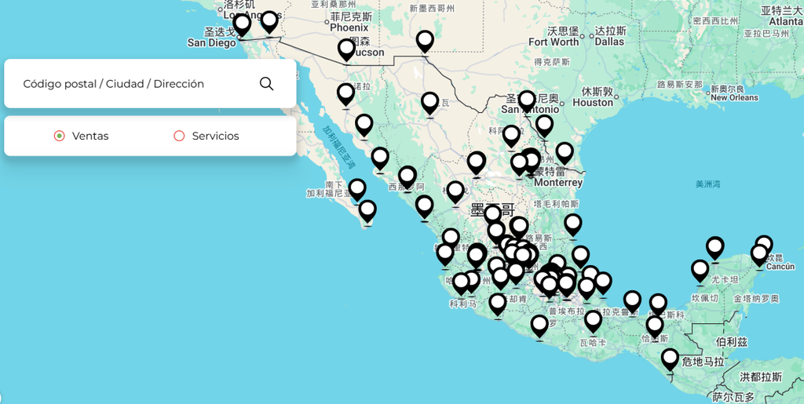

**图6 比亚迪在墨西哥的销售门店分布（来源：BYD Mexico）**

在金融支持上，比亚迪以“消费者金融+经销商金融”的双层机制撬动市场需求。面向消费者，企业与本地金融机构合作推出购车融资方案，以降低新能源车购买门槛；面向经销商，则通过库存融资、风险管理与售后配套等工具稳固渠道合作关系，增强销售体系的稳定性。

在生态配套上，比亚迪推进“车—桩—网”一体化布局。除与本地伙伴合作完善充电网络外，企业还通过电动出租车项目、与优步的合作等方式，把产品销售延伸至公共出行与平台场景，尝试将品牌、基础设施与高频使用场景联结起来。

3.1.3 嵌入基础与分析过渡

上述举措并不只是市场扩张手段，它们同时构成了比亚迪在墨西哥开展本地化嵌入的实践基础。产品、渠道、金融和生态布局，使企业与政府部门、经销商体系、金融机构、平台企业及消费者之间逐步建立起稳定联结，也为后文从社会、网络和地域三个维度评估其嵌入程度提供了现实基础。

在制度与治理层面，比亚迪通过政府沟通、原产地规则应对和行业协会参与，增强了与政策环境的接触；在社会文化层面，通过中墨共治团队、高校合作、公共交通项目和体育赞助等方式扩大了本地社会可见度；在公共传播层面，则围绕绿色发展和技术品牌主动塑造企业叙事。也就是说，这一阶段更接近“嵌入基础的形成”，而非深度嵌入的完成。<sup>[31]</sup>

因此，第三章后半部分不再重复罗列企业动作，而是转向回答一个更关键的问题：这些举措究竟在多大程度上转化为了社会、网络与地域层面的真实嵌入。

**3.2 比亚迪墨西哥市场嵌入程度**

基于上述进入路径与初步联结，本节根据赫斯（Hess，2004）的三维嵌入性框架<sup>[32]</sup>，分别从社会嵌入、网络嵌入和地域嵌入三个维度，评估比亚迪在墨西哥的市场嵌入程度，并进一步说明“市场进入已取得进展”与“生产落地仍然受阻”之间的张力。

3.2.1 社会嵌入

社会嵌入关注是企业与东道国社会文化、制度环境、社群网络的适配融合程度，以及企业与当地公众、社群建立的情感联结和深层信任关系，其核心在于企业固有的“基因”与跨文化的适配度，以及本土社会认同的构建。比亚迪在墨西哥的社会嵌入整体处于浅层触达阶段，虽搭建起多元化社会连接触点，但尚未形成深层社会信任与深度文化融合。

从企业“基因”的跨文化适配度来看，比亚迪的产品、制度、产业三大核心基因与墨西哥市场呈现表层契合、深层错位的特征。就产品而言，比亚迪深耕大众消费市场形成的高性价比、高配置的产品特质，与墨西哥中产阶层为主的消费结构形成核心需求契合。但墨西哥汽车市场长期受欧美系、日系品牌培育，消费者注重汽车的品牌口碑、耐用性与售后服务，比亚迪易被贴上“低价替代”标签，产品认知存在一定错位。制度层面上，比亚迪政企协同的经营基因在公共交通项目中得到初步应用，与墨西哥联邦及地方政府建立了一定的合作关系。但墨西哥联邦制下地方政府自主权大，政策连续性弱，且受地缘政治制约，比亚迪难以与当地形成长期稳定的政企协同关系。产业层面，比亚迪在国内形成的“电池-整车-充电设施”全产业链垂直整合能力是其核心产业基因，该能力在技术层面具备跨地域迁移的可能性，与墨西哥推动新能源汽车产业发展的目标形成表层契合。但目前而言，建厂迟滞使得比亚迪全产业链布局基因无法在墨西哥实现本土化落地，难以与本地产业体系形成深度联动，只能以“整车+配套设施”的成品输出形式参与本地产业发展。

3.2.2 网络嵌入

网络嵌入聚焦企业与东道国各类经济主体构建的生产、供应链、销售、金融等全链条关系网络，包含关系维度与结构维度，其中关系维度强调合作紧密程度、信任基础，结构维度关注网络覆盖完整性、资源联动性。比亚迪在墨西哥的网络嵌入是三个维度中嵌入程度最深、最核心的维度，整体处于中高度嵌入状态，销售、金融、生态等环节的网络布局完善，但生产制造环节的空白成为明显短板，制约了全产业链网络的构建。

结构维度上，比亚迪在墨西哥构建了覆盖“产品、销售、金融 、生态”的完整合作网络，参与主体涵盖经销商、金融机构、能源企业、平台企业、政府机构等多元经济行动者。市场表现上，比亚迪自2023年3月进军墨西哥市场以来，已售出逾8万辆汽车。2025年上半年的销售数据显示，比亚迪已成为墨西哥第四大汽车品牌，仅次于日产、通用汽车和大众汽车。同时，比亚迪在墨西哥市场产品覆盖广泛，精准匹配家庭乘用车、网约车、电动公交、商用车等多种场景，高度契合墨西哥中产阶层出行需求以及城市运营需求。在渠道网络建设上，比亚迪采用与本地经销商、本地头部汽车集团合作的方式，以及与利物浦的创新性合作，快速完成了核心城市网点覆盖，建立起全国范围内的销售与服务网络。此外，通过与桑坦德银行、BBVA Mexico等本土金融机构的合作，比亚迪不仅为消费者提供了购车融资支持，更通过经销商库存融资等金融工具，将合作伙伴的利益与比亚迪的销售业绩深度绑定，显著提升了渠道伙伴的忠诚度与抗风险能力。生态配套层面，比亚迪与本地能源企业合作布局充电网络，与优步达成战略合作，构建“车、桩、网”一体化生态，完成生态层面的延伸。然而在生产与供应链层面，尽管早在2024年初比亚迪就宣布了建厂计划，但时至今日，生产基地的选址与建设仍未落地，比亚迪当前仍以整车出口为主，在本土化生产方面严重滞后，生产环节的本地嵌入处于完全空白状态，直接制约了全产业链网络嵌入的完整性与可持续性。

关系维度上，比亚迪与本地合作方的关系并非简单交易关系，而是通过长期协议、利益绑定、资源共享，构建起高粘性、高信任的合作关系，逐步实现从单次交易向长期共生的转变。渠道层面，比亚迪通过经销商库存融资、市场指导等金融与运营支持，将经销商利益与企业销售业绩深度绑定，提升渠道忠诚度与抗风险能力；政企合作层面，又通过长期商用车项目合作，与墨西哥政府及大型企业建立稳定的合作信任；生态与文化合作层面，与充电企业、优步等的长期战略合作，实现资源共享与互利共赢；奇瓦瓦自治大学等高校签署产学研合作协议，双方将围绕学术、科研及技术合作建立战略伙伴关系，推动可持续交通领域的学生培养与创新实践，合作的深度与持续性不断提升。

3.2.3 地域嵌入

地域嵌入核心是企业在东道国地理空间的覆盖程度、地域资源的利用与适配，既包括企业对本地地理空间、产业资源、基础设施的吸收利用，也包括企业受本地制度环境、地理条件的制约。比亚迪在墨西哥的地域嵌入已实现核心区域空间覆盖与基础资源利用，制度适配初见成效，但尚未实现深度扎根与全维度融合，整体处于中度向深度扎根过渡阶段，布局灵活性较高但风险抵御能力不足。

在地理空间与资源利用上，比亚迪的布局聚焦核心区域，但对产业核心资源的利用存在空白。销售服务网络重点布局在墨西哥城、蒙特雷、瓜达拉哈拉等经济发达、消费能力强的核心城市，实现对墨西哥主要消费市场的空间覆盖；生产基地选址重点考察新莱昂州、圣路易斯波托西州等墨西哥汽车产业集群区域，瞄准本地成熟的汽车产业地理空间，试图借助产业集群效应实现生产环节的深度扎根，尽管建厂计划暂停，但已完成核心产业空间的筛选与规划，空间锚定的方向与目标明确。比亚迪利用本地经销商、金融机构等商业资源构建经营网络，对墨西哥本地基础资源实现了较好的吸收利用，但由于建厂的停滞，未与本地零部件供应商、汽车生产配套企业建立合作，也未实现本地产业技术、生产工人等核心产业资源的吸收与适配，产业资源利用的深度严重不足。

在政策应对方面，比亚迪在墨西哥的政治嵌入面临着美国的政策压力与墨西哥的政策不确定性，整体而言处于合规优先、积极应对、持续发展状态。其在墨西哥面临的核心挑战之一是如何应对《美墨加协定》（USMCA）的原产地规则要求，2026年该协定进入审查期，给比亚迪带来了巨大的政策不全定性与风险。对此，比亚迪坚持合规优先的原则，积极应对各类政策变化，同时通过参与电动出行协会（EMA），开始尝试从被动合规转向主动参与规则塑造。与联邦政府及新莱昂州、墨西哥州等地方政府对于建厂选址的沟通与电动出行的合作，也为其争取了一定的政策空间。在基础设施嵌入层面，比亚迪积极布局充电网络、推动电动出租车项目，试图将自身产品与墨西哥的城市交通基础设施绑定。但这种“车-桩-网”的生态构建仍处于起步阶段，尚未形成与本土能源体系、城市规划深度融合的协同。

此外，由于比亚迪在墨西哥尚未实现生产环节的深度扎根，未过度依赖某一区域的产业资源、政策优惠或合作网络，因此暂未形成赫斯理论中提及的“空间锁定”风险，企业在地域布局上仍具备较高的灵活性。但这也导致企业在面对地缘政治冲击、地方政策调整时，缺乏与特定地域的深度利益绑定，风险抵御能力不足，成为地域嵌入深化的潜在制约因素。

3.2.4 维度互动与综合评价

赫斯的三重嵌入性理论强调社会、网络、地域嵌入并非孤立存在，而是相互影响、相互支撑的有机整体。但从比亚迪在墨西哥的实际情况来看，浅层的社会嵌入导致品牌信任不足，直接制约了网络嵌入中消费者端的市场拓展与用户粘性的提升；地域嵌入的生产制造缺失，使得网络嵌入无法向生产供应链延伸，也导致社会嵌入缺乏就业、产业贡献等实质性支撑，难以形成深层本土认同；而网络嵌入在贸易上形成的优势，没能有效转化为社会嵌入的品牌认同与，也没能推动地域嵌入的资源整合能。三重嵌入处于各自为战又相互制约的状态，协同性严重不足，成为制约企业进一步发展的重要因素。

而综合三个维度的嵌入程度来看，比亚迪在墨西哥的市场嵌入以高强度的网络嵌入为引领与核心，强大的销售网络与金融合作支撑了销量的快速增长，使其在短期内取得了令人瞩目的市场表现。但社会嵌入的浅层触达与地域嵌入的非深度扎根此形成短板，具体表现为生产制造的停滞基层、社会信任的缺失，以及品牌认知的刻板印象尚未彻底扭转，这使其在面对地缘政治冲击、本土利益集团抵制或舆论环境逆转时，缺乏足够的应对空间与缓冲余地。其中，如表2所示，迟滞的生产落地成为比亚迪在墨西哥进一步发展的核心瓶颈，不仅制约了地域嵌入的深化，也影响了社会嵌入与网络嵌入的协同升级。

**表2 比亚迪墨西哥建厂停滞对三个嵌入维度的影响**

| **维度** | **核心阻碍** | **主要影响** |
| --- | --- | --- |
| 社会嵌入 | 1.难以与本地产业体系形成深度联动 2.在当地社区就业贡献、产业工人培养等方面的实质性投入不足 | 1.只能以“整车+配套设施”的成品输出形式参与本地产业发展，产业链垂直整合能力优势难以发挥 2.与墨西哥基层社会的连接上仍处于悬浮状态。 |
| 网络嵌入 | 本土化生产环节空白，无法形成全链条经济合作网络 | 制约了全产业链网络嵌入的完整性与可持续性 |
| 地域嵌入 | 未与本地零部件供应商、汽车生产配套企业建立深度合作 未实现本地产业技术、生产工人等核心产业资源的吸收与适配 | 产业资源利用的深度不足，未形成地域锁定与长期扎根能力 |

图表来源：笔者自制

**4. 比亚迪在墨西哥推迟建厂的归因分析**

虽然比亚迪在墨西哥采取了诸多本地化措施，但其建厂计划仍不得不暂停。这不仅仅是企业层面上的考虑，其背后更有复杂的国际政治经济因素的影响。我们将根据前文第二章中提出的理论框架，将比亚迪建厂事件所涉及的中美墨三国的具体情境代入该框架，进行归因分析。见下图：

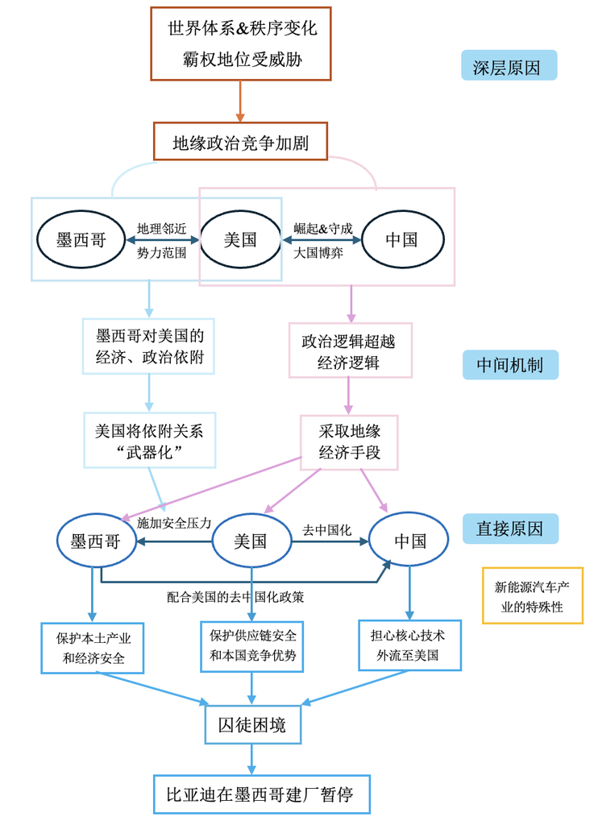

**图9 比亚迪在墨西哥推迟建厂的归因分析框架**

图表来源：笔者自制

**4.1 “唐罗主义”——美国的“势力范围”之争**

在比亚迪墨西哥建厂事件中，地缘政治博弈主要表现为势力范围上的竞争。中美都是具有非常强大的地缘政治潜力和全球地缘政治利益的大国。对于美国来说，拉美是对其国家安全和利益至关重要的战略“后院”，墨西哥更是其势力范围的核心。特朗普再次上台后重提“门罗主义”（The Monroe Doctrine），并形成新的“唐罗主义”（The “Donroe Doctrine”），强调西半球是“我们”的半球（This is OUR Hemisphere），试图巩固和强化在西半球以美国为中心的势力范围。在2025年底，特朗普政府发布新的《国家安全战略》报告，其中着重提出“西半球优先战略”（a hemisphere-first strategy），将西半球——尤其是关键咽喉要道和该地区存在的大国竞争态势——置于美国战略的核心位置。

近年来，随着中拉在贸易、能源、基建和科技等领域内的合作持续拓展深化，美国的战略焦虑急剧上升，越来越将中国在拉美日益扩大的影响视为对其区域控制权的重大挑战，将排挤打压中国作为其西半球优先战略的核心目标。为此美国采取多种措施，包括建立美拉合作机制、供应链重组、投资安全审查、关税威胁等，试图清除中国在西半球的战略存在，把拉美牢牢绑定在美国主导的安全与经济体系中，为美国利益服务。比亚迪在墨西哥建厂是中国经济和科技力量在拉美影响力扩展的契机，在宏观层面上威胁了美国在拉美的排他性势力范围布局，因此受到美国的极力阻挠，成为建厂推迟的深层结构性原因。

**4.2 “中心-外围”结构——墨西哥对美国的依附关系**

地理上的邻近性容易造成经济上的依附，进而形成国家间结构性的依附关系。墨西哥的特殊性在于它与美国直接接壤，是对于美国来说战略价值最高的“后院”，也是美国势力范围的核心。墨西哥与美国毗邻为它带来了经济上的利好，例如近岸外包和友岸外包的机会；但另一方面，这种邻近性也成为了“地理诅咒”（geographical curse）。地理不仅塑造经济机会，更决定政治选择空间。在地理因素的影响下，墨西哥对美国市场的贸易依赖度极高，2024年墨西哥高达81.3%的出口商品流向了美国；在汽车产业，墨西哥作为全球重要汽车生产国，70%左右的产量销往美国。<sup>[33]</sup>

墨西哥作为世界体系中的“外围国”，其经济增长依赖于美国这样的“中心国”。墨西哥的产业结构是由美国的需求决定的，与此同时，这种贸易交换被刻意维持在不平等的权力结构之下，导致墨西哥长期被锁定在全球产业链的低端、贸易呈现单一化特征。墨西哥对美国的这种结构性、制度化的依附导致其丧失了一定的政策自主性，限制了其政治选择，在美国施压下不得不进行让步。2024-2025年，美国多次以惩罚性关税为威胁向墨西哥施压，要求其限制中国投资，墨西哥因此多次配合美国提升对中国产汽车的关税，并最终通过法案，确认从2026年1月1日起将乘用车关税从20%提升到最高50%。<sup>[34]</sup>同时，由于美国对来自墨西哥的中国电动车威胁自身市场的担忧，墨西哥政府取消了对比亚迪建厂时低价公共用地或减税等投资优惠政策，成为比亚迪推迟建厂的一大原因。墨西哥的这些让步本质上是由于处于美国势力范围核心导致的经济依附带来的政治上的脆弱性。

此外，这种依附关系不仅是贸易和产业上的依附，制度锁定也是其中的关键一环，使得外围国进一步丧失政策自主权，从而加强政治上的依附。在制度规则层面上，美国通过贸易协定来牵制墨西哥，以此来巩固自身在墨西哥的势力范围覆盖。墨西哥自1994年就加入了《北美自由贸易协定》（NAFTA），2020年进一步升级到《美墨加协定》（USMCA）。这一次制度规则上的变更很大程度上是出于地缘政治动因：《美墨加协定》规定汽车产业的区域内产值比例须提升至75%以上；任何一方若与“非市场经济国家”签署自贸协定，其他方有权退出。这些规定都防止美国在北美的势力范围被中国侵犯，并试图堵住中国借道墨西哥进入美国市场的后门，以此来应对中国的崛起，遏制中国在拉美的战略影响力。与此同时，《美墨加协定》将于2026年7月进行首次强制性联合审查，墨西哥必须展示合规诚意，与美国政策保持一致，才能有望换取协定的延长和关税豁免。在此背景下，墨西哥总统克劳迪娅·辛鲍姆（Claudia Sheinbaum）强调墨西哥的经济战略始终以自由贸易协定为优先，特别是与USMCA的协议；并表示尚无具体计划让中国电动汽车制造商在墨西哥建厂<sup>[35]</sup>。根据《美墨加协定》作出的承诺始终是墨西哥的首要任务，因此墨西哥对国投资持审慎态度，配合美国“去中国化”的要求，这也导致最终墨西哥“献祭”比亚迪的建厂计划，以此来换取美国对墨西哥的关税和其他贸易优惠政策。

**4.3 “网络性权力”享有者——美国将依附关系“武器化”**

在比亚迪墨西哥建厂事件中，美墨关系鲜明地展现了武器化相互依存的权力机制。墨西哥在贸易、投资和侨汇等方面对美国经济和金融系统的高度依赖赋予了美国巨大的结构性权力，使其能将这种经济上的相互依赖关系转化为实现其政治目标的潜在工具。由于在全球金融、技术、贸易网络中处于“中心节点”位置，美国可以凭借“瓶颈效应”享有“网络性权力”，并利用该网络控制权将墨西哥对其市场的依赖转化为向墨西哥施压的武器，使墨西哥不得不服从美国的国家战略要求，排斥中国企业在墨的直接投资。虽然墨西哥政府希望吸引中国投资，但美墨之间的贸易关系对墨西哥更为重要，因此在“选边站”过程中墨西哥为了维护自身利益最大化而选择了配合美国。

具体到比亚迪，由于美国担忧比亚迪通过“后门”进入美国威胁其国家安全，从而向墨西哥施压，威胁对墨西哥进口汽车征收200%的关税。墨西哥选择配合美国限制中国投资，暂停对中国电动汽车制造商的优惠政策并取消进口关税豁免政策，这也是比亚迪取消在墨西哥建厂计划的一大政策原因。与此同时，通过《美墨加协定》中的数据自由流动条款和北美供应链深度整合，美国具有全景监控墨西哥境内企业生产活动的能力，若比亚迪在美墨边境附近建厂，其核心技术有较大的外流风险。

**4.4 新能源汽车产业的特殊性**

比亚迪在墨西哥建厂推迟事件的特殊性不仅在于墨西哥的战略枢纽位置，还需要考量新能源汽车产业的特殊性。墨西哥建厂计划搁置后，比亚迪执行副总裁李柯在接受采访时表示，“地缘政治对汽车产业影响很大，现在所有人都在重新思考他们在其他国家的战略。我们希望局势更明朗之后再做决定。”<sup>[36]</sup>那么新能源汽车产业为什么受到地缘政治的显著影响呢？这需要从技术、能源和产业主权三个方面来解释。从技术来说，新能源汽车是一个具有高技术含量的产业，包括电池技术、智能驾驶、数据系统等，这些都是国家竞争力的来源。新能源汽车的发展水平也可能在未来决定一国在科技产业链中的主导权，容易引起地缘政治竞争和保护主义；在能源层面，一方面，新能源汽车的电池供应链高度依赖关键矿产，如锂、稀土、石墨等，易造成供应链风险。这些资源的不均匀分布和加工技术的垄断都易引起地缘政治竞争并成为国家之间相互扼制的筹码。另一方面，面对全球气候变暖，新能源汽车产业是各国能源转型的关键一环，影响国家能源安全；最后，在产业主权上，汽车产业是很多国家的支柱产业，对经济发展和就业有重要影响，中国新能源汽车企业“井喷式”出海、占据全球大部分产能，引起很多国家汽车行业的生存危机，加剧地缘政治的担忧和关税等限制措施。

与此同时，美国的政治和贸易动向一直是比亚迪暂停选址、选择观望、并最终彻底停止建厂计划的最大阻碍。比亚迪的电池、电控等核心零件和技术系统仍主要在中国生产，满足USMCA的75%原产地规则较为困难，这也导致美国总统特朗普的贸易政策、尤其是关税政策对于比亚迪在墨西哥建厂的前景影响较大。美国在USMCA之外还通过了“大而美”法案（One Big Beautiful Bill Act, OBBBA），引入严苛的“被禁止外国实体”（Prohibited Foreign Entity, PFE）概念，从而堵住如第三国产能“再本土化”等中国企业采取的绕道策略<sup>[38]</sup>。美国的这些举措都进一步加大“去中国化”力度，对中国新能源汽车出口企业构成了准入壁垒，并建立一套更深层系统的内部合规门槛，让比亚迪的“墨西哥跳板”策略无法实行，也切断了比亚迪通过技术渗透等方式参与美国市场的路径。

最终比亚迪在墨西哥建厂计划的搁置就是地缘政治逻辑战胜纯粹的商业逻辑的典型表现。企业商业扩张目标被迫让位于地缘政治竞争下的国家经济安全。

**4.5 贸易投资“泛政治化”——中美墨共同采取地缘经济手段**

经济泛安全化的根源在于国家之间的权力关系转变和旧有国际秩序的瓦解。在2026年2月进行的慕尼黑安全会议的官方报告的标题是“正遭摧毁”（Under Destruction），大多数领导人也表示自1945年以来延续数十年的世界秩序已经不复存在。<sup>[39]</sup>具体来讲，美国给世界带来的风险和不确定性越来越大。经济泛安全化成为近年来美国作为霸权国对外政策的突出特征，它借安全理由将不对称的相互依赖关系武器化，切断网络连线来破坏他国日渐成长的权力基础，以此来维持其结构性的霸权地位和由其主导的国际秩序。

美国为追求经济安全而使用的泛安全化手段主要表现为以下几点：首先，推动关键产业地理布局的回流和近岸化发展。美国近年推进的近岸外包和友岸外包就旨在形成北美贸易壁垒，降低对中国的贸易依存度，从而加强自身供应链的韧性和安全性。墨西哥因其地理位置自然成为美国“近岸外包”的核心节点，与美国在贸易上的合作更加紧密；但与此同时，由于美国正将国家安全利益置于一切之上，墨西哥越来越被要求按照美国的安全考量来调整贸易和跨国直接投资政策。其次，经济泛安全化也主要表现为投资政策中基于国别的风险识别与歧视。这种风险推定逻辑并不提供充分证据，简单推定商品、服务和投资的国别属性以及企业的国别属性本身就等同于风险，并进一步采取供应链重塑、投资审查等措施加以阻碍。中国作为美国目前最大的战略性竞争对手，其在拉美的经贸活动尤其受到美国的警惕和限制。第三，收紧涉及高新技术等在内的敏感信息的战略管控，构筑技术及信息的安全壁垒。美国全力保持自身在高新技术领域的相对优势，排除他国对美国市场的技术和信息渗透。因此，美国担心比亚迪将墨西哥作为“跳板”进入美国本土市场进行技术渗透，并削弱美国本土企业的竞争力。最后，征收惩罚性高额关税和实施其他限制性经贸措施，减少来自外部的进口竞争，保护国内相关企业及产业的发展。关税政策的不稳定性和高额关税威胁都导致跨国企业难以进行对外投资以实现自身的全球战略布局。

针对比亚迪在墨西哥建厂推迟事件，经济泛安全化体现在各个阶段和层次上，最终这种安全压力压倒了正常的经济考量。首先表现在观念建构中。在2024年初比亚迪正式宣布在墨西哥建厂后不久美国就表达了对比亚迪建厂的担忧。在基于国别的风险识别中美国对来自中国的商品和投资尤为敏感，这也促成美国将比亚迪的商业投资计划重新解读成安全威胁，认为比亚迪希望通过墨西哥这个“跳板”进入北美市场，带来数据安全和网络安全风险和激烈竞争，从而威胁到美国的产业主权和在西半球的势力范围。因此，美国自身率先采取行动对中国电动汽车企业进行国家安全风险调查，开启反倾销和反补贴案件调查，上调中国电动汽车进口税率等，从而保护本土电动汽车市场免受中国竞争的冲击。对于比亚迪来说，其核心零部件（电池、电机）深植中国供应链，短期内难以满足USMCA要求的“实质性转型”标准，因此美国关税政策的不稳定性对其商业利益影响较大，是建厂推迟的一大原因。

接下来，美国将对比亚迪建厂的安全压力传导到墨西哥，利用墨西哥对其市场的深度依赖和制度上的牵制要求墨西哥配合美国限制中国投资。美国以USMCA审查、边境事务、高额关税等作为威胁，美国贸易代表也指出“墨西哥需要做出抉择——是选择进入美国市场，还是服务于中国的利益”。墨西哥由于无法承担与白宫发生摩擦、美墨关系紧张带来的经济和安全成本，因此不得不在选边中倒向美国以换取自身的经济安全。在美国政府施压下，墨西哥政府暂停对中国电动汽车制造商的优惠政策。墨西哥高层与比亚迪高管的会晤中明确表示，“不会像过去那样给予汽车制造商优惠政策”<sup>[40]</sup>。

与此同时，中国政府也在考虑国家的技术安全。新能源汽车行业是一个数据和信息敏感的行业，比亚迪工厂选址又邻近美国，这引起了中国对比亚迪的智能汽车技术流入美国的担忧，因此商务部推迟了对比亚迪墨西哥建厂的审批。比亚迪自主决策的海外投资由此被建构为国家技术主权安全和防止技术外溢。比亚迪的技术被视为国家战略资产和竞争力，在此次审批中，技术主权显然优先于市场扩张和企业利益，是经济泛安全化的典型表现。另外，墨西哥与美国地理位置接近是推迟批准的最主要担忧因素，这也反映出中美双方都将墨西哥的地理位置重构成安全威胁，并采取相应的地缘经济手段以维护自身的政治经济安全。

**4.6 囚徒困境——中美墨三方拒绝合作的僵局**

随着中美之间的在政治和经贸上的博弈持续升温，墨西哥由于其特殊的地理位置和产业布局而成为中美竞争中的重要阵地和全球价值链重组的关键支点。中国、美国和墨西哥之间形成了复杂的三角贸易格局。这一三角关系并非对称的权力关系：一方面，墨西哥在中美两大强国之间更像是一颗棋子，面临“双重代理人困境”（Double Agent Dilemma），自主选择权被削弱，被迫在两者间选边站；另一方面，由于美墨之间长期的结构性依附关系和自贸协定优势，中国被两者合力排斥，导致中墨关系较为脆弱、具有工具性。

在非对称关系之下，中美墨三方都因为希望实现自身利益最大化而最终陷入“囚徒困境”的博弈论模型中。在中美墨三角关系中，三方都选择“背叛”——美国对中、墨极限施压，堵住“后门”、限制比亚迪等中国电动汽车产业进入美国市场；中国担心比亚迪的智能汽车技术通过墨西哥泄露到美国，从而迟迟未审批通过比亚迪在墨西哥的建厂计划，比亚迪也选择规避风险、暂时观望；墨西哥则迫于美国压力，牺牲比亚迪的建厂计划以求自身损失的最小化。在这种博弈论格局下，比亚迪同时受到来自中美墨三方的压力和阻挠，其建厂计划自然无法得以顺利实施。见下表：

**表3 中美墨三方在“囚徒困境”下的博弈格局表**

| **博弈方** | **可选策略** | **理性选择（从各自角度看）** |
| --- | --- | --- |
| 墨西哥 | 合作：全力支持比亚迪建厂 | 选择背叛：担心美国惩罚，牺牲比亚迪以自保 |
|  | 背叛：迫于美国压力，牺牲比亚迪 | 选择背叛：担心美国惩罚，牺牲比亚迪以自保 |
| 中国/比亚迪 | 合作：坚定推进投资 | 选择背叛：担心美国干预、技术外流，暂停建厂 |
|  | 背叛：暂停项目，规避风险 | 选择背叛：担心美国干预、技术外流，暂停建厂 |
| 美国 | 合作：默许中墨合作 | 选择背叛：遏制中国产业侵占美国市场，施压墨西哥，威胁审查、关税 |
|  | 背叛：极限施压，堵截后门 | 选择背叛：遏制中国产业侵占美国市场，施压墨西哥，威胁审查、关税 |

图表来源：笔者自制

综合归因分析框架图和上述具体案例阐释，可以清晰地看出比亚迪在墨西哥建厂背后各层级上和各主体间的阻碍因素：它既包括宏观上的世界体系和秩序、国家间的结构性权力关系，也涉及国家自身的安全需要和政治战略；既包括微观层面上新能源汽车产业自身的特殊性，也涉及各个国家采取的具体政策措施、合作态度和博弈格局。在该复杂的体系下，各种因素层层传导，最终中美墨三方同时将自身的安全目标放在首位，并且都基于对安全威胁的最大化预估来行动，导致三方同时阻碍比亚迪建厂投资行为，比亚迪在三者的夹缝中寻求企业战略自主性和商业利益，但仍无法满足各方的需求，因此只能暂时终止在墨西哥的建厂计划，待局势和制度更稳定后再继续其在北美的业务规划。

**5. 比亚迪墨西哥建厂受阻的多维解释框架：提出、检验与修正**

**5.1 框架提出与问题界定**

第四章已经说明，比亚迪在墨西哥建厂受阻并非一般意义上的企业经营失误，而是地缘政治竞争、经济泛安全化与三方政策博弈共同作用下的结构性结果。本章的任务是在此基础上回答两个更进一步的问题：这一解释能否超出单一个案，成为理解中国新能源汽车企业在敏感地区推进生产性嵌入的分析工具；企业又应依据哪些变量，判断某一项目更适合深度建厂、合资推进，还是授权、组装与轻资产布局。

为此，本章将前文识别出的关键约束提炼为一个多维解释框架，并通过比较案例加以检验。本文提出四个核心维度：

A 维度是“地缘政治锚定强度”，关注东道国所处的外部政策上限；

B 维度是“外部压力可规避性”，关注外部压力究竟是可以通过商业调整化解，还是直接针对企业身份与核心技术；

C 维度是“母国—东道国政策协同度”，关注母国与东道国之间是否存在足够的政策协同，使项目能够在冲击中继续推进；

D 维度是“制度性政策交换空间”，关注东道国是否仍然掌握足够的政策工具，为企业提供可兑现的激励与制度便利。

这四个维度并非并列罗列，而是分别对应不同层次的判断任务。A、B 主要界定项目所处环境的外生边界，用来识别“能不能做”；C、D 则主要界定在既定边界下的执行空间，用来识别“做不做得成”。这一框架要解决的既是一个学术问题，即如何更准确地解释“市场进入成功而生产落地受阻”的现象；也是一个实践问题，即中国新能源汽车企业在选择出海路径时，如何尽早判断某一东道国更适合深度建厂、合资推进，还是更适合授权、组装和轻资产布局。

为了避免框架停留在概念层面，本文先对四个维度的经验含义加以界定。A 维度主要观察东道国与关键第三方市场之间的地理邻近性、贸易依赖和制度绑定程度；B 维度主要观察外部阻力究竟针对“生产地点”还是针对“企业身份”；C 维度主要观察母国与东道国在项目推进上的战略意愿是否一致，以及外部冲击后这种协同能否维持；D 维度主要观察东道国是否仍有能力提供税收、土地、审批和产业配套等真实可用的政策资源。四个维度合在一起，构成了本文从比亚迪墨西哥个案走向行业与全球视野的第一步。

**5.2 维度界定与指标设计**

四个维度之所以能够构成一个可用于比较检验的分析框架，关键不只在于它们具有理论来源，更在于它们能够被操作化。换言之，第五章要提出的不是一组抽象判断，而是一套能够被识别、被比较、被用于前期研判的中观分析工具。因此，下面分别对 A、B、C、D 四个维度的理论基础、概念定义与衡量指标作出界定。

5.2.1 地缘政治锚定强度

A 维度“地缘政治锚定强度”主要来源于地缘政治竞争、依附理论与武器化相互依存理论。它强调，东道国并不是抽象的投资地点，而是嵌入在特定权力结构中的政治空间；东道国与关键第三方市场之间的邻近性、依赖性和规则绑定程度越高，其对特定外资项目的政策自主空间就越有限。基于这一逻辑，本文将 A 维度界定为：东道国与关键第三方市场在空间位点、贸易依赖和制度协议上的绑定深度。对墨西哥而言，邻近美国、深度嵌入北美贸易体系并受 USMCA 规则约束，意味着其对华产业政策从一开始就存在较低上限。

在实证层面，A 维度的衡量指标主要包括三项。第一，地理区位耦合度，即东道国是否处于第三方市场的核心战略半径或安全防线内，这决定了外部压力的物理传导强度。第二，贸易非对称依赖度，即东道国对第三方市场的出口集中程度和市场依赖程度，这决定其在承受报复风险时的脆弱性。第三，制度协议绑定深度，即东道国是否受制于类似 USMCA 这类具有排他性、审查性或安全例外色彩的正式规则安排。三项指标合在一起，用于判断某一东道国的外部天花板究竟有多低。

5.2.2 外部压力可规避性

B 维度“外部压力可规避性”主要来自经济泛安全化理论。它要区分的是两类性质完全不同的外部压力：一类是成本性或合规性摩擦，企业仍可通过本地化生产、供应链调整和制度适配予以缓解；另一类则直接锚定企业国别身份、技术属性和安全标签，因此不再只是成本问题，而是资格问题。基于这一逻辑，本文将 B 维度界定为：跨国投资项目在面临地缘政治干预时，其所受阻力究竟是可通过商业调整加以对冲，还是已经转化为直接针对企业身份与核心技术的硬约束。比亚迪墨西哥之所以具有代表性，恰恰在于美国担忧的已不只是汽车产地，而是“中国新能源汽车企业”是否借墨西哥进入北美体系。

在实证层面，B 维度的衡量指标主要包括三项。第一，母国身份属性，即第三方市场是否将企业国别本身视作风险来源，使身份标签凌驾于原产地规则之上。第二，行业技术敏感度，即项目所属产业是否涉及核心技术、数据系统或战略供应链，从而更容易被纳入安全化叙事。第三，供应链网络安全穿透度，即第三方市场是否对价值链实施穿透式审查，要求整个生产网络实现去母国化或“纯洁化”。这三项指标共同决定，企业面对的究竟是“可规避摩擦”还是“不可规避压力”。

5.2.3 母国—东道国政策协同度

C 维度“母国—东道国政策协同度”对应双层博弈和政策协同的分析逻辑。跨国建厂并不只是企业与东道国之间的市场交易，还取决于母国是否支持技术和资本外流、东道国是否愿意在外部压力下继续推进合作。若母国担忧技术外流，东道国又顾忌第三方报复，即便双方口头上都欢迎投资，项目仍可能在审批与执行链条中陷入停滞。基于这一逻辑，本文将 C 维度界定为：母国与东道国在特定投资项目上的战略意愿对齐程度，以及双方在第三方压力干预下维持行政与技术审批“双向通行”的能力。

在实证层面，C 维度的衡量指标主要包括两项。第一，双边话语叙事对齐度，即双方政府在公报、政策文件和公开表态中，是否围绕特定项目形成较稳定的正面共识和合作叙事。第二，外部冲击后的政策恢复韧性，即在第三方市场释放明确压力之后，双边行政链条能否从停滞、迟疑或降温状态中恢复推进。前者用于识别战略意愿是否一致，后者用于识别这种一致性是否经得起冲击。

5.2.4 制度性政策交换空间

D 维度“制度性政策交换空间”对应政策交换空间的分析逻辑。这里真正关键的不是东道国是否口头欢迎投资，而是它是否仍然拥有足够的政策工具，把这种欢迎转化为现实可执行的激励与制度便利。基于这一逻辑，本文将 D 维度界定为：东道国政府在面临第三方地缘政治压力时，仍能基于本国发展利益，自主制定并执行针对特定外资项目的非对称激励与保障政策的权力余地。

在实证层面，D 维度的衡量指标主要包括两项。第一，非对称激励工具的拨付自由度，即东道国是否仍能提供税收减免、土地支持、基础设施配套和产业优惠，而这些承诺是否会在第三方介入后失效。第二，行政审批的排他性自主权，即东道国在项目准入、产业许可和政策执行中，是否仍然掌握不受第三方直接掣肘的最终决定权。前者衡量的是“拿得出多少筹码”，后者衡量的是“这些筹码能否真正兑现”。

**表4 四维度核心问题、理论来源及主要观察点**

**维度**

**核心问题**

**理论来源**

**主要观察点**

A 地缘政治锚定强度

判断东道国所处的外部政策上限

1. 地缘政治竞争
2. 依附理论
3. 武器化相互依存
1. 地理区位耦合度
2. 贸易非对称依赖度
3. 制度协议绑定深度

B 外部压力可规避性

判断外部压力是可调整摩擦还是身份化硬约束

1. 经济泛安全化
1. 母国身份属性
2. 行业技术敏感度
3. 供应链网络安全穿透度

C 母国—东道国政策协同度

判断双边是否能在冲击下维持项目推进

1. 双层博弈
2. 政策协同
1. 双边话语叙事对齐度
2. 外部冲击后的政策恢复韧性

D 制度性政策交换空间

判断东道国能否把欢迎投资转化为可执行激励

1. 政策交换空间
1. 非对称激励工具的拨付自由度
2. 行政审批的排他性自主权

图表来源：笔者自制

四个维度之间并不存在完全对称的关系。A、B 更接近结构性约束，决定项目所处环境的基本难度和上限；C、D 更接近执行性变量，决定在既定环境下项目能否被推动、被延续或被重新设计。也正因为如此，本文在后文并不把四个维度视作等权并列指标，而是通过跨案例比较识别它们在解释优先级上的差异。

**5.3 跨案例比较与维度验证**

为了更清楚地识别各维度在不同情境中的作用方式，本文采用“小范围、强针对性”的横向比较策略。案例选择遵循两个标准：第一，尽量保持中国车企和汽车产业属性的相似性，以减少企业差异对比较结果的干扰；第二，在地缘位置、制度环境和政策空间上形成足够差异，以观察四个维度如何共同作用。基于这一标准，本文以比亚迪墨西哥为核心案例，以比亚迪巴西为恒定对照，再引入奇瑞—Ebro 西班牙项目作为补充案例。这样的安排既可以通过比亚迪巴西控制企业差异，又可以借助奇瑞—Ebro 项目呈现“受约束但仍可推进”的中间状态。截至 2025 年，比亚迪巴西项目已实现首车下线并进入本地组装阶段，但完全达产仍需时间<sup>[41][42]</sup>；奇瑞—Ebro 西班牙项目则在 2024 年签署合作后重启原日产工厂，并于 2025 年继续推进产能和就业布局，合资与存量工厂盘活路径已经基本确立<sup>[43][44]</sup>。

从比较结果看，比亚迪墨西哥的特殊性首先体现在 A 维度，即地缘政治锚定强度。与巴西和西班牙相比，墨西哥与美国距离最近、制度绑定最深，因此其外部政策上限最低<sup>[14][15]</sup>。这里的问题并不只是招商诚意，而是政策上限本身更低。其次，在 B 维度即外部压力可规避性上，比亚迪墨西哥遭遇的阻力带有鲜明的身份化特征：项目受阻并不主要源于成本或单一技术标准，而是因为“中国新能源汽车企业”这一身份本身被纳入美国的安全化叙事<sup>[5][6][7]</sup>。相比之下，比亚迪巴西与奇瑞—Ebro 西班牙项目虽然同样处在规则约束之下，但其压力并未像墨西哥案例那样直接转化为对项目身份的整体否定<sup>[41][42][43][44]</sup>。

再看 C 和 D 维度，即母国—东道国政策协同度和制度性政策交换空间，差异同样明显。比亚迪巴西项目并非没有波折，但在较低地缘锚定和较强政策支持的条件下，项目仍然从投资承诺推进到本地组装和首车下线，说明中巴之间存在相对稳定的政策协同，巴西政府也掌握较强的激励兑现能力<sup>[41][42]</sup>。奇瑞—Ebro 西班牙项目则表明，即便处在受欧盟规则和关税环境约束的中度压力场中，东道国和企业仍可通过合资、旧厂重启和“再工业化／就业修复”叙事打开部分空间<sup>[43][44]</sup>。与之相比，墨西哥的关键问题在于：母国—东道国政策协同不足，且东道国可兑现的制度性政策工具有限，导致项目既没有被稳定托住，也难以被有效激励。

**表5 跨案例比较的关键观察点**

| **案例** | **生产性嵌入结果（截至2025年）** | **主要约束来源** | **主要支撑来源** | **对框架的启示** |
| --- | --- | --- | --- | --- |
| 比亚迪墨西哥 | 建厂计划仍未落地，项目处于延宕状态 | 靠美地缘锚定强，身份化安全压力强 | 母国与东道国协同不足，激励空间有限 | A、B 决定基本上限，C、D 难以形成补救 |
| 比亚迪巴西 | 已启动本地组装并实现首车下线，项目向实质生产推进 | 外部约束相对较弱，但仍受建设进度与劳工事件影响 | 中巴政策协同较强，地方政府激励可兑现 | 当 A、B 未封死空间时，C、D 可以推动落地 |
| 奇瑞—Ebro 西班牙项目 | 旧厂重启，合资与本土品牌合作落地，项目推进但节奏调整 | 欧盟规则与关税环境形成中度约束 | 合资模式、存量工厂和地方再工业化需求提供支撑 | 在中度约束下，可通过合作模式重组 C、D |

图表来源：笔者自制

注：本表不对各维度进行“高／低”“强／弱”的半定量打分，而是以定性比较方式概括案例差异，避免将结构性变量机械量化。资料来源：作者根据公开资料整理。

三案比较表明，四个维度在解释链条中并不处于同一层次。A、B 更接近前置性约束，决定项目是否仍适合生产性嵌入；C、D 则更接近执行性条件，决定项目在既定边界内能否被稳定推进。为了更清楚地呈现这一点，下文结合相关案例，分别说明四个维度的具体作用方式。

A 维度首先体现为地缘政治锚定强度对项目路径的前置性限定。比亚迪墨西哥与比亚迪巴西的对照已经说明，地缘锚定强度会显著改变东道国的政策上限；而宁德时代在北美由全资建厂设想转向与福特合作的授权路径，则进一步表明，当东道国或目标市场处在强烈的对华安全化环境中时，即便企业掌握较强技术与资本优势，传统 FDI 路径也可能提前失效<sup>[45][46]</sup>。由此可见，A 维度并非一般背景条件，而是可能直接限定项目的进入方式。

B 维度体现的是外部压力的性质差异。比亚迪墨西哥之所以受阻，并不只是因为成本高、规则严，而是因为“中国新能源汽车企业”这一身份本身被安全化。与之形成鲜明对照的是 20 世纪 80 年代日系车企在美国的扩张。当时美国施加的主要是配额和原产地约束，日本车企仍可通过在美建厂实现本地化规避<sup>[47][48]</sup>；这说明只要压力主要针对产地而非身份，企业仍然存在通过生产布局调整化解摩擦的空间。B 维度所区分的，正是“可通过商业调整对冲的压力”与“无法通过商业调整消解的身份化压力”。

C 维度体现的是母国与东道国之间的政策协同能否为项目提供持续支撑。华为在巴西的经历提供了一个补充例证：巴西并非地缘锚定最强的国家，但在通信等高度敏感产业中，一旦母国对技术外流保持高度谨慎，东道国又在外部压力下摇摆不定，项目推进仍可能受到严重掣肘<sup>[49][50]</sup>。由此可见，政策协同并不只是 A、B 的附属结果；在高技术敏感行业中，C 维度本身就可能成为决定项目能否持续推进的关键变量。

D 维度体现的是东道国制度性政策交换空间的现实含义。奇瑞—Ebro 西班牙项目的意义正在于此。西班牙并非处在完全宽松的制度环境中，但地方政府与企业仍可通过旧厂盘活、就业叙事和合资安排，把有限的制度空间转化为现实推进能力<sup>[43][44]</sup>。D 维度所衡量的因此不是东道国是否“欢迎外资”这样的口头态度，而是它能否把政策承诺转化为可执行的激励与制度便利。

综合上述比较可以看到，A、B 主要决定项目上限与压力性质，C、D 则决定项目在既定边界内是否仍具有推进空间。由此形成的解释链条是：先由 A、B 判断项目是否仍适合生产性嵌入，再由 C、D 解释项目能否在既定边界内被稳定推进。也正是在这一基础上，企业能动性才有必要被进一步引入，用以解释不同企业为何会在相近环境中形成不同的落地路径。

**5.4 框架修正与企业能动性**

横向比较进一步表明，四维框架已经能够解释比亚迪墨西哥为何受阻，但若要把它提升为一个更有层次感的判断工具，还需要引入企业层面的能动性变量。原因在于，现实中的项目成败并不只由地缘环境和政府政策决定，企业自身是否拥有足够筹码去撬动东道国支持、重组合作方式和调适进入路径，同样会影响最终结果。

基于此，本文在四维框架基础上进一步提出 E 维度，即“企业能动性”或“企业撬动能力”。这一维度关注的不是企业能否突破 A、B 所设定的外部天花板，而是在 A、B 既定的前提下，企业手里究竟还有多少筹码去影响 C 和 D。具体而言，它包括企业是否掌握足够的技术、资本、品牌和供应链组织能力，是否能通过合资、授权、旧厂收购、就业承诺、产业配套和叙事重构等方式增强东道国的合作意愿，并提升项目的现实可执行性。E 维度并不替代 A—D，而是用来解释为什么处在相近环境中的不同企业，最终仍可能走出不同路径。

在这一修正之后，框架的层级关系更适合被理解为一个“前因—闸门—结果”的两阶段判断模型，而不是所有变量同时直接指向结果的并列网络。第一道闸门是“结构可行性判断”，主要由 A 维度即地缘政治锚定强度和 B 维度即外部压力可规避性共同决定，用来回答项目在结构上是否还具备生产性嵌入的基本可行性；第二道闸门是“执行可行性判断”，主要由 C 维度即母国—东道国政策协同度和 D 维度即制度性政策交换空间共同决定，用来回答在既定结构边界内，项目是否还具备现实推进条件。E 维度即企业能动性并不直接改变 A、B 所决定的外部边界，而是主要通过撬动 C、D 来影响第二道闸门能否被打开。这种表达方式借鉴了前因—中介—结果的因果链思路和 stage-gate 式的闸门逻辑，更能清楚体现各变量之间的先后关系和解释顺序。

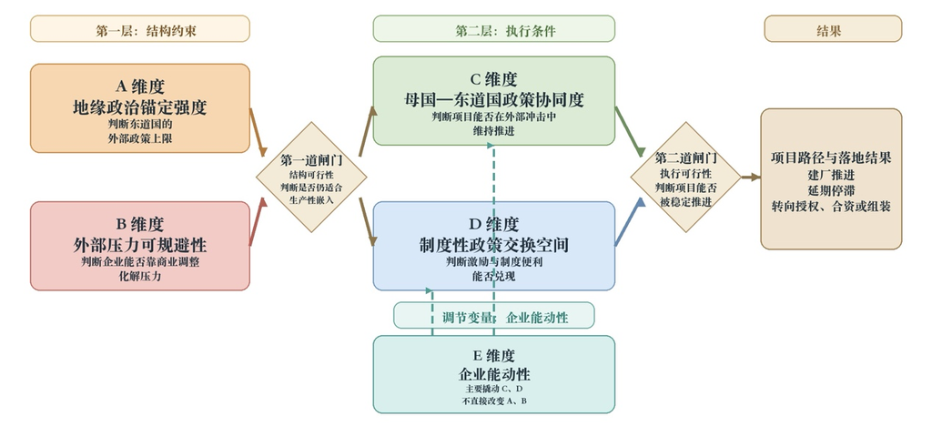

**图10 第五章分析框架的两阶段判断逻辑**

注：本图借鉴前因—中介—结果的因果链思路与 stage-gate 式闸门逻辑绘制。A、B 共同构成第一道闸门，用于判断生产性嵌入是否具备基本结构可行性；C、D 构成第二道闸门，用于判断项目在既定边界内能否被稳定推进；E 体现企业对第二道闸门的撬动能力，不直接改变 A、B。资料来源：作者根据本文分析绘制。

从这个意义上说，第五章的贡献不只是提出一个新的维度清单，而是把单案归因上升为一个具有解释优先级的分析框架：当地缘政治天花板过低、外部阻力又直接针对企业身份时，企业不应再把深度本地化建厂视为默认路径；相反，更可行的选择可能是轻资产进入、技术授权、合资合作，或者暂缓生产性嵌入。只有当 A、B 没有把空间完全封死，而 C、D 又具有可撬动性时，E 才可能真正发挥作用。也正是在这个基础上，本文得以从比亚迪墨西哥个案进一步走向对中国新能源汽车企业全球化路径的更一般性判断。

**6. 总结与反思**

**6.1 研究总结**

本文以比亚迪墨西哥建厂暂停事件为核心案例，立足新能源汽车出海的典型场景，结合地缘政治竞争、经济泛安全化、武器化相互依存、依附理论等理论视角，对此事件进行了深入拆解与归因，系统挖掘了地缘政治竞争下中国车企出海的困境。研究发现，比亚迪在墨西哥已实现市场销量领先、渠道覆盖完善、生态配套初步形成的商业成功，却在本地化生产落地上停滞，这一矛盾并非企业的经营失误，而是地缘政治竞争下母国、东道国、第三方市场三方博弈叠加的结果。

从事件脉络来看，墨西哥凭借其独特的地理区位优势、广阔的市场空间、有利的制度环境，以及与比亚迪全球布局的高度协同等优势，成为比亚迪全球化布局的战略支点，企业也通过商用先行、乘用车跟进、本土化运营的渐进路径快速打开市场。但建厂计划从多方争抢落地、到反复推迟、再到最终搁置，被地缘政治力量显著影响着。美国以关税威胁、规则封锁、安全审查为手段，将墨美经济依附关系武器化，强制墨西哥收紧对华投资政策；墨西哥受地缘锚定与制度绑定约束，政策自主性被严重压缩，从积极引资转向主动阻碍审批；中国出于核心技术安全与地缘风险考量，对项目实施战略性审批延迟。三方在 “安全优先”逻辑下陷入囚徒困境，共同终结了这一符合经济理性的投资项目。

在此基础上，本文进一步提炼出地缘政治锚定效应、压力可规避性、母国-东道国政策协同度、制度性政策交换空间四维分析框架，并通过比亚迪巴西建厂成功、宁德时代北美项目调整、日系车企美国扩张等跨案例对比验证框架有效性。结果表明，地缘政治锚定效应是前置决定性因素，直接决定东道国外资政策自主空间的大小；压力可规避性是边界条件，当阻力指向母国身份与核心技术时，传统商业对冲策略将失效；母国-东道国政策协同度是重要调节变量，其高低直接影响项目在外部冲击下的抗风险能力；制度性政策交换空间是关键约束变量，东道国主权能动性的强弱决定了外资激励政策的落地效果与投资契约的稳定性。四大维度相互影响、相互制约，共同构成了判定跨国投资项目成败的核心分析体系。而比亚迪墨西哥建厂项目的失败，本质是全球价值链重构背景下，新兴技术企业出海遭遇守成大国地缘围堵下的出海困境，其背后反映了当代国际经济秩序中商业理性让渡于地缘政治逻辑的深层趋势。

**6.2 理论反思**

在理论贡献上，其一，本文创新性提出地缘政治锚定效应、压力可规避性、母国-东道国政策协同度、制度性政策交换空间四维分析框架，为跨国投资与企业全球化的研究提供了新的视角与框架。这一框架打破“母国-东道国”的双边分析范式，构建了“母国-东道国-第三方市场”三方互动的分析框架，将第三方地缘干预纳为跨国投资核心影响变量，揭示了全球化背景下跨国投资并非对称博弈的本质，弥补了现有研究对地缘政治因素考量不足的缺陷。其二，拓展了依附理论与武器化相互依存理论的应用场景，通过墨西哥案例验证了两大理论在数字与新能源产业的适用性，证实传统经济依附已升级为制度绑定、主权让渡、政策胁迫的新型依附形态，为解释数字与新能源时代价值链中的权力传导机制提供了新的实证证据。其三，明确经济泛安全化的行业差异性，指出新能源汽车等技术密集型产业，因涉及供应链主权、核心技术、数据安全，更容易被纳入国家安全框架，成为地缘竞争的核心靶点，修正了泛安全化研究笼统化、宏观化的不足。

在理论不足上，首先，本研究以案例分析与跨案例对比为主，最后进一步创新性提出了四维分析框架并通过跨案例对比验证框架有效性，但框架的指标量化、权重赋值尚未完善，理论细节有待进一步补充研究。其次，对第三方市场（美国）的政策决策内部机制、墨西哥国内联邦与地方政府、产业界与政界的利益博弈分析不够深入，权力传导的微观路径仍需细化。最后，对企业在地缘约束下的战略能动性挖掘不足，未充分探讨企业如何通过模式创新突破结构性困境。

**6.3 实践反思**

比亚迪墨西哥建厂事件，为中国新能源汽车乃至整个技术型制造业出海，提供了极具警示性与指导性的实践经验，整体而言，企业可以从风险研判、布局策略、政企协同三个层面反思优化。

企业需要提前系统研究判断地缘政治风险。企业海外布局不能仅考量经济成本与市场潜力，更应当建立地缘政治风险的评估体系，对东道国地缘政治环境进行全面研究判断。可优先选择地缘锚定弱、政策自主空间大的国家布局重资产产能；对墨西哥等强锚定国家，放弃全资建厂模式，转向轻资产运营、技术授权、本地合作等迂回路径。

第二，在地缘敏感区域，出海模式需从生产嵌入转向价值重构。摆脱“产品出口-本地建厂”的线性思维，针对地缘敏感区域，聚焦品牌运营、渠道深耕、生态搭建、技术服务等非生产环节，降低地缘政治冲击风险；同时严格切割与第三方敏感市场的关联，明确产能仅服务东道国及区域市场，避免被贴上“跳板”标签，对进一步出海造成阻碍。

第三，政企协同形成合力，政府支持形成保障防线。针对地缘政治影响下，中国新能源汽车等战略新兴企业的出海困境，政府层面可加强双边与多边贸易合作，为企业海外投资构建制度性保障，降低东道国的政策不确定性；同时积极参与全球产业规则制定，反对贸易保护主义与身份标签化，维护中国企业的合法权益。而企业需主动与母国、东道国政府沟通，及时报备战略布局，平衡商业扩张与国家技术安全，避免陷入三方博弈的被动局面。

**6.4 研究展望**

面向未来，中国技术型制造业全球化已进入“地缘约束常态化”的新阶段，本研究的四维分析框架仍有较大拓展空间。一是推进框架量化与标准化，选取全球多国新能源汽车投资案例开展大样本实证，优化指标体系与评估模型，提升框架的实操性。二是深化三方动态博弈研究，构建博弈模型分析不同政策工具对投资结果的影响，精准刻画权力传导与策略互动机制。三是聚焦关注新兴企业如何在地缘政治的围堵下实现颇具发展，探索全球化的新模式与新路径，如技术授权、合资合作、离岸贸易、区域联盟等新型出海模式，为企业在地缘围堵下实现可持续全球化提供具体方案。四是拓展研究场景，将框架应用于电池、光伏、智能制造等其他技术敏感产业，检验理论的跨行业适用性。

总体而言，比亚迪墨西哥建厂暂停事件并非中国新能源车企出海的终点，而是企业在全球化进程中必须面对的阶段性挑战。在全球新能源汽车产业竞争日趋激烈与地缘政治格局复杂多变的背景下，中国企业唯有精准研判风险、优化布局策略、深化多方协同，才能实现从产品出海到品牌出海再到生态出海的跨越，在全球价值链重构中占据有利地位。

**参考文献**

[1] 经济观察网. 中汽协：2025年汽车总销量增速超预期 自主乘用车市占率近七成[N]. 2026-01-15.

[2] 人民网. 中汽协：2024年我国汽车产销再创新高[N]. 2025-01-13.

[3] 人民日报. 2023年我国汽车产销均首超3000万辆[N]. 2024-01-12.

[4] Xinhua. Closer China-Latin America economic, trade cooperation benefits both[N]. 2026-02-11.

[5] Reuters. Chinese electric carmaker BYD denies pause on Mexico plant plans[N]. 2024-09-03.

[6] Financial Times. China delays approval of BYD's Mexico plant amid fears tech could leak to US[N]. 2025-03-19.

[7] Bloomberg. BYD Shelves Plans to Build Major Mexico Car Plant Over Trump’s Trade War[N]. 2025-07-02.

[8] Jenkins, R. China’s Belt and Road Initiative in Latin America: What Has Changed?[J]. Journal of Current Chinese Affairs, 2022, 51(1): 13-39.

[9] Ray, R., and E. Dussel Peters. China-Latin America and the Caribbean Economic Bulletin, 2025 Edition[R]. Boston University Global Development Policy Center, 2025.

[10] Dussel Peters, E. Monitor of Chinese OFDI in Latin America and the Caribbean 2025[R]. Red ALC-China, 2025.

[11] Gereffi, G. Oportunidades y dificultades del nearshoring en México[J]. Foro Internacional, 2025.

[12] Gereffi, G. Nearshoring in Mexico: Diverse Options for Industrial Upgrading[R]. CEPAL, 2025.

[13] OECD. Managing Security Implications of International Investment: Policy Developments in a Changing World[R]. OECD, 2024.

[14] USTR. 2024 Report on the Operation of the United States-Mexico-Canada Agreement (USMCA) with Respect to Trade in Automotive Goods[R]. 2024.

[15] Lester, S. China’s Role in the USMCA Review[R]. Rice University’s Baker Institute for Public Policy, 2026.

[16] П.Я.巴克拉诺夫,周建英.论当代地缘政治范畴[J].俄罗斯中亚东欧研究,2004,(06):89-93.

[17] 胡志丁, 张喆, 马腾, 等. 在学科发展的演变中理解和把握地缘政治及地缘政治学—兼论对地缘环境研究的启示 [J]. 地理科学,2022,42(1):54-64.

[18] 田野等.走向整合的国际竞争理论构建：地缘竞争、技术竞争与国际制度竞国际政治研究,2024(01):9-27+5.

[19] Prebisch, Raúl. The Economic Development of Latin America and Its Principal Problems[J]. New York: United Nations, 1950.

[20] 王正毅. 国际政治经济学通论[M]. 北京：北京大学出版社，2010：204.

[21] Henry Farrell and Abraham L. Newman, “Weaponized Interdependence: How Global Economic Networks Shape State Coercion”[J]. International Security, Vol. 44, No. 1，2019, p. 45.

[22] Daniel W. Drezner, Henry Farrell, and Abraham L. Newman (eds.), The Uses and Abuses of Weaponized Interdependence[J]. The Brookings Institution, 2021, p. 1.

[23] Sun Chenghao, Wang Yexu and Dong Yifan: Mechanisms of the weaponization of interdependence[J]. Chinese Social Sciences Today, 2024.

[24] 陈友骏等. 经济泛安全化的全球挑战与中国因应[M]. 上海国际问题研究院，2024（34）：3-8.

[25]王中美. 经济泛安全化辨析与约束路径[J].亚太经济,2025,(03):17-34. DOI:10.16407/j.cnki.1000-6052.2025.03.001.

[26] 任琳，孙振民.经济安全化与霸权的网络性权力[J].世界经济与政治, 2021, (06):83-109+158-159.

[27] 李承柱,李祗辉.世界经济的网络化与战略竞争——复合地缘经济学的产生[J].国际社会科学杂志(中文版),2023,40(01):78-93+6+9.

[28] 胡志丁，毕诗瑶.理解西方地缘经济与地缘经济学[J].地理科学进展，2024，43(02)：387-401.

[29] 李冰.车展对话｜李云飞：比亚迪深化全球化战略，腾势D9将在欧洲上市[EB/OL]. (2025-09-02)[2026-02-22]. https://m.bjnews.com.cn/detail/1756776828168595.html.

[30] 中华人民共和国商务部.对外投资合作国别（地区）指南——墨西哥（2025年版）[EB/OL]. (2025)[2026-02-25].https://www.mofcom.gov.cn/dl/gbdqzn/upload/moxige.pdf.

[31] 林雪萍.大出海：中国制造全球出征的关口和突破[M/OL].北京：中信出版集团，2025 [2026-01-29]. 第一章“中国企业大出海”.

[32] Hess M. 'Spatial' relationships? Towards a reconceptualization of embeddedness[J/OL]. Progress in Human Geography, 2004, 28(2): 165-186

[33]缪培源，吴昊. 墨西哥成为“世界工厂”还有多远[N].《环球》杂志，2024年9月23日.

[34]安丽敏.新法案：中国汽车出口墨西哥关税升至50%｜出海·地缘[N]. 财新，，2025年12月11日.

[35]Óscar Goytia.Sheinbaum Denies Mexico Chinese Plant;BYD Teases Announcement[N]. Mexico Business News,11/29/2024.

[36] 箫雨.比亚迪搁置墨西哥建厂计划，副总裁李柯回应[N]. 凤凰网科技，2025年7月3日.

[37]MBN staff. Mexico Auto Industry Sells 1.5 Million Vehicles in 2025[N]. Mexico Business News, 01/07/2026.

[38]康军，盛楚宜，杨铭琦.《大而美法案》被禁止的外国实体条款解读[N]. 金杜律师事务所，2025年9月10日.

[39]李超，张毅荣.慕安会出台年度报告，聚焦美国破坏与秩序崩塌[N]. 新华社，2026年2月10日.

[40] 周纯粼.美国施压，墨西哥对中国的电动车关上“激励大门”[N]. 澎湃新闻，2024年4月22日.

[41] Reuters. BYD factory delayed in Brazil to be fully functional by end-2026, says official[N]. 2025-05-12.

[42] UOL News. BYD opens new factory in Brazil and reveals its first electric car assembled in the country[N]. 2025-07-01.

[43] Reuters. Chinese automaker Chery to produce cars in former Nissan plant in Barcelona[N]. 2024-04-19.

[44] El País. Ebro ampliará en 60.000 metros cuadrados su actividad industrial en la Zona Franca para hacer frente a su crecimiento[N]. 2025-06-19.

[45] Reuters. Ford to use CATL technology for Michigan battery plant[N]. 2023-02-13.

[46] Financial Times. Ford defends CATL battery deal as US lawmakers attack China tie-up[N]. 2023-09-26.

[47] Manger, M. S. Investing in Protection: The Politics of Preferential Trade Agreements between North and South[M]. Cambridge: Cambridge University Press, 2009.

[48] Weisman, S. R. Japan Auto Firms Expanding U.S. Output[N]. The New York Times, 1985-07-27.

[49] Reuters. Brazil will not exclude Huawei from 5G auction, minister says[N]. 2021-06-25.

[50] Reuters. Brazilian carriers pick Huawei gear in 5G rollout despite U.S. pressure[N]. 2021-11-05.

The Delay of BYD's Mexico Plant: An International Political Economy Perspective

LIU Jingyi, PI Enyan, LIU Ailin; Supervisor: LU Yanping

This article examines the delay of BYD's Mexico plant and addresses a core puzzle in international political economy: why could a Chinese new energy vehicle firm achieve sales growth, channel expansion, and a certain degree of social, network, and territorial embedding in Mexico, yet still fail to complete production embedding through local manufacturing? Drawing on geopolitical competition, dependency theory, weaponized interdependence, and economic securitization, the paper combines case analysis with cross-case comparison to investigate BYD's market entry, localization practices, and the mechanism behind the stalled project. It argues that the delay was not simply a result of firm-level miscalculation, but of the combined effects of geopolitical rivalry, institutional constraints, and triadic strategic interaction. On this basis, the article develops an analytical framework for assessing the overseas risks faced by Chinese high-technology manufacturing in sensitive regions and derives practical implications.

Keywords: BYD; Mexico; new energy vehicle overseas expansion; production embedding; economic securitization